# MD 11 Preview Season 2627

Windows split at each substitution (subs within 3 minutes are grouped). Short windows are noisy, so read alongside the minutes column.  
X @Barts78 · Bluesky @barts78 · Mastodon @DrBarts · GitHub Barts78 · LinkedIn Phil-barter · Data: Opta

Match vs Season Average

[figure not shown]

Home Pass Maps

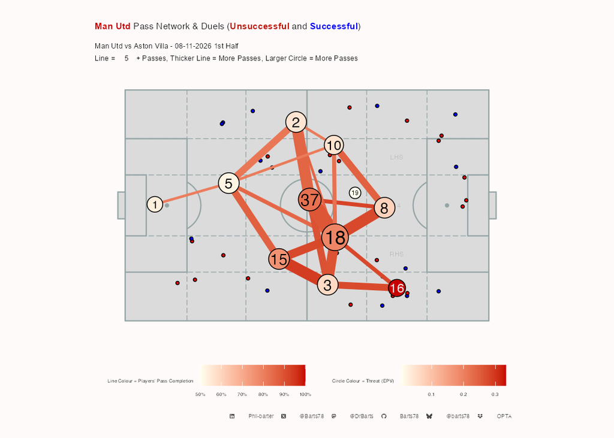

Away Pass Maps

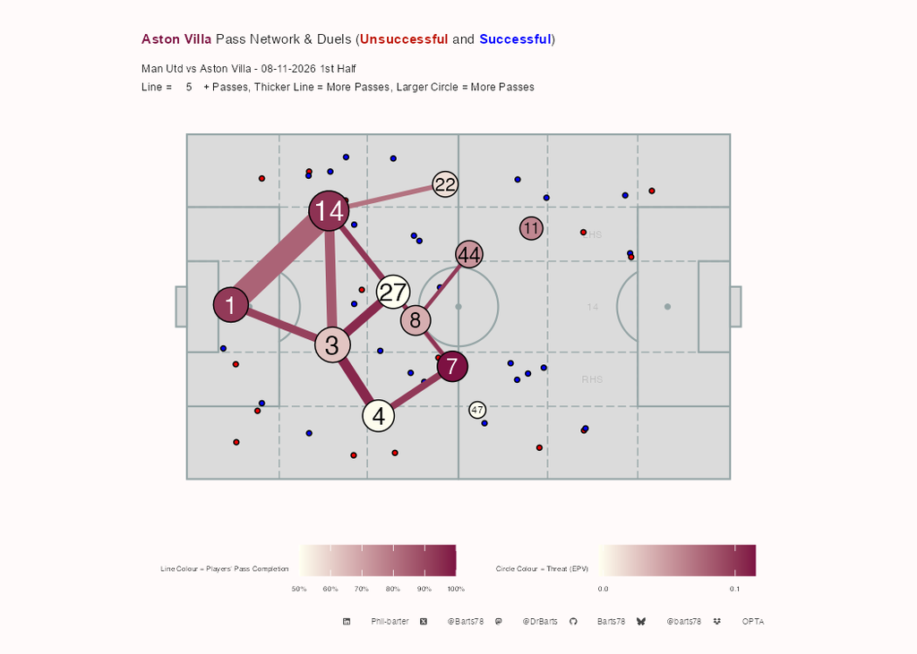

Home Pass Maps by Time

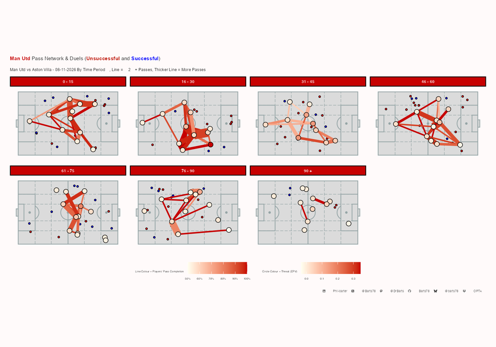

Away Pass Maps by Time

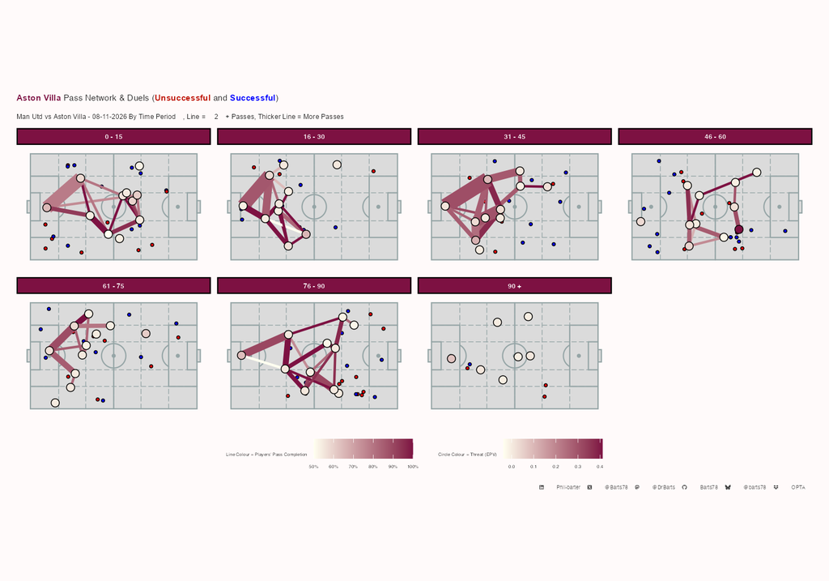

Home Attacking Pass Maps

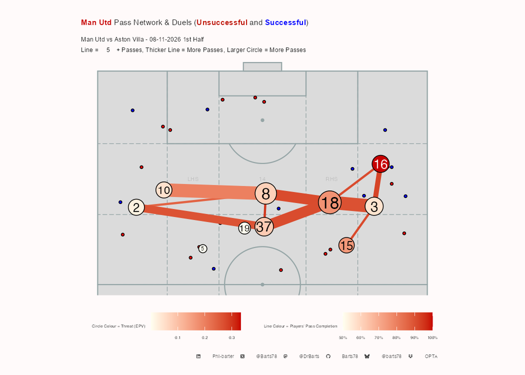

Away Attacking Pass Maps

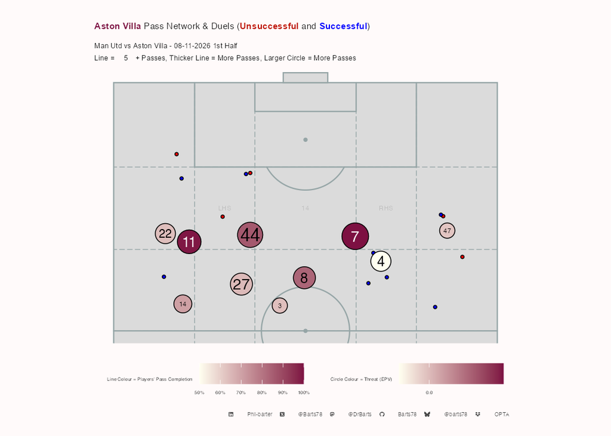

Home Attacking Pass Maps by Time

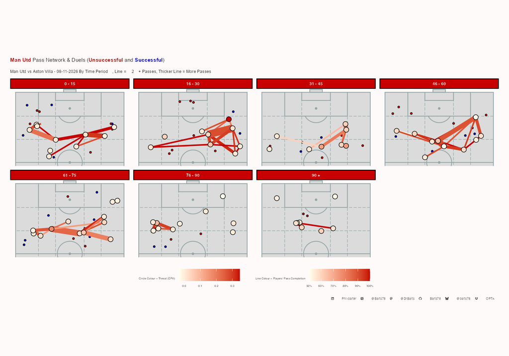

Away Attacking Pass Maps by Time

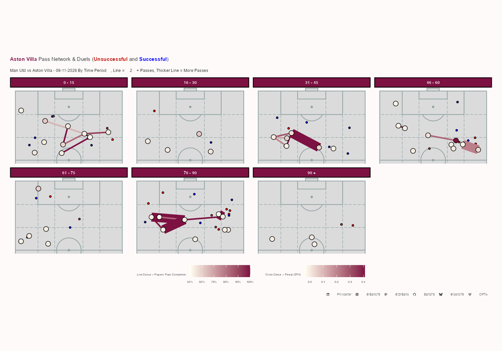

**Pass Connections by Passer**

Man Utd Open Play Passing connections

Man Utd vs Aston Villa - 08-11-2026 | Completed passes only, min 5 per pair. Passer Completion % = all of the passer's attempts

|  | Completed Passes | % of Passer's Completions | % of Receiver's Receptions | Passer Completion % | Long Passes | Final Third Passes | PK Box Passes | Crosses | Key Passes | Prog Passes | EPV | EPV / Pass | Pass Time |
| --- | --- | --- | --- | --- | --- | --- | --- | --- | --- | --- | --- | --- | --- |
| Amad Diallo |  |  |  |  |  |  |  |  |  |  |  |  |  |
| Youri Tielemans | 8 | 40% | 16% | 83% | 0 | 7 | 1 | 0 | 1 | 0 | 0.026 | 0.003 | 2.25 |
| Ayden Heaven |  |  |  |  |  |  |  |  |  |  |  |  |  |
| Bruno Fernandes | 6 | 22% | 10% | 96% | 0 | 1 | 0 | 0 | 0 | 0 | 0.009 | 0.002 | 2.50 |
| Kobbie Mainoo | 6 | 22% | 11% | 96% | 0 | 0 | 0 | 0 | 0 | 0 | 0.010 | 0.002 | 3.67 |
| Leny Yoro | 5 | 18% | 13% | 96% | 0 | 0 | 0 | 0 | 0 | 0 | 0.004 | 0.001 | 2.60 |
| Bruno Fernandes |  |  |  |  |  |  |  |  |  |  |  |  |  |
| Amad Diallo | 5 | 10% | 20% | 84% | 1 | 0 | 0 | 0 | 0 | 1 | 0.043 | 0.009 | 4.60 |
| Diogo Dalot | 5 | 10% | 19% | 84% | 0 | 5 | 0 | 0 | 0 | 0 | 0.055 | 0.011 | 2.00 |
| Matheus Cunha | 10 | 19% | 28% | 84% | 0 | 5 | 0 | 0 | 1 | 2 | 0.079 | 0.008 | 2.20 |
| Patrick Dorgu | 5 | 10% | 50% | 84% | 0 | 1 | 0 | 0 | 0 | 3 | 0.060 | 0.012 | 2.20 |
| Youri Tielemans | 6 | 12% | 12% | 84% | 0 | 3 | 0 | 0 | 0 | 2 | 0.042 | 0.007 | 1.67 |
| Diogo Dalot |  |  |  |  |  |  |  |  |  |  |  |  |  |
| Kobbie Mainoo | 7 | 28% | 13% | 81% | 0 | 2 | 0 | 0 | 0 | 1 | 0.011 | 0.002 | 3.86 |
| Matheus Cunha | 5 | 20% | 14% | 81% | 0 | 0 | 0 | 0 | 0 | 0 | 0.024 | 0.005 | 3.00 |
| Harry Maguire |  |  |  |  |  |  |  |  |  |  |  |  |  |
| Leny Yoro | 5 | 28% | 13% | 78% | 0 | 0 | 0 | 0 | 0 | 0 | 0.005 | 0.001 | 3.20 |
| Kobbie Mainoo |  |  |  |  |  |  |  |  |  |  |  |  |  |
| Amad Diallo | 5 | 8% | 20% | 91% | 1 | 2 | 1 | 0 | 1 | 1 | 0.091 | 0.018 | 4.40 |
| Ayden Heaven | 7 | 11% | 33% | 91% | 0 | 1 | 0 | 0 | 0 | 0 | 0.020 | 0.003 | 2.29 |
| Bruno Fernandes | 13 | 20% | 21% | 91% | 1 | 4 | 0 | 0 | 0 | 2 | 0.070 | 0.005 | 2.54 |
| Diogo Dalot | 7 | 11% | 27% | 91% | 0 | 2 | 0 | 0 | 0 | 0 | 0.015 | 0.002 | 2.14 |
| Noussair Mazraoui | 6 | 9% | 15% | 91% | 1 | 3 | 0 | 0 | 0 | 0 | 0.011 | 0.002 | 3.17 |
| Youri Tielemans | 12 | 19% | 24% | 91% | 0 | 2 | 0 | 0 | 0 | 0 | 0.020 | 0.002 | 2.08 |
| Leny Yoro |  |  |  |  |  |  |  |  |  |  |  |  |  |
| Kobbie Mainoo | 8 | 16% | 15% | 98% | 0 | 2 | 0 | 0 | 0 | 1 | 0.024 | 0.003 | 2.50 |
| Noussair Mazraoui | 16 | 32% | 41% | 98% | 0 | 0 | 0 | 0 | 0 | 0 | 0.028 | 0.002 | 2.88 |
| Youri Tielemans | 5 | 10% | 10% | 98% | 0 | 1 | 0 | 0 | 0 | 0 | 0.020 | 0.004 | 1.60 |
| Matheus Cunha |  |  |  |  |  |  |  |  |  |  |  |  |  |
| Bruno Fernandes | 11 | 39% | 18% | 82% | 0 | 5 | 0 | 0 | 1 | 2 | 0.042 | 0.004 | 3.00 |
| Youri Tielemans | 5 | 18% | 10% | 82% | 0 | 1 | 1 | 0 | 1 | 1 | 0.055 | 0.011 | 1.80 |
| Noussair Mazraoui |  |  |  |  |  |  |  |  |  |  |  |  |  |
| Amad Diallo | 8 | 20% | 32% | 85% | 0 | 2 | 0 | 0 | 0 | 2 | 0.050 | 0.006 | 3.62 |
| Leny Yoro | 9 | 23% | 23% | 85% | 0 | 1 | 0 | 0 | 0 | 0 | 0.019 | 0.002 | 2.44 |
| Youri Tielemans | 9 | 23% | 18% | 85% | 0 | 6 | 1 | 0 | 1 | 1 | 0.056 | 0.006 | 2.44 |
| Senne Lammens |  |  |  |  |  |  |  |  |  |  |  |  |  |
| Harry Maguire | 5 | 29% | 31% | 85% | 0 | 0 | 0 | 0 | 0 | 0 | 0.007 | 0.001 | 5.20 |
| Youri Tielemans |  |  |  |  |  |  |  |  |  |  |  |  |  |
| Bruno Fernandes | 12 | 23% | 19% | 90% | 0 | 6 | 2 | 0 | 1 | 3 | 0.064 | 0.005 | 2.25 |
| Kobbie Mainoo | 11 | 21% | 21% | 90% | 0 | 2 | 0 | 0 | 0 | 2 | 0.016 | 0.001 | 2.64 |
| Leny Yoro | 6 | 11% | 15% | 90% | 0 | 1 | 0 | 0 | 0 | 0 | 0.014 | 0.002 | 3.50 |
| Noussair Mazraoui | 6 | 11% | 15% | 90% | 0 | 4 | 0 | 0 | 0 | 0 | 0.029 | 0.005 | 2.17 |

X @Barts78 · Bluesky @barts78 · Mastodon @DrBarts · GitHub Barts78 · LinkedIn Phil-barter · Data: Opta

**Pass Connections by Receiver**

Man Utd Open Play Passing connections

Man Utd vs Aston Villa - 08-11-2026 | Completed passes only, min 5 per pair. Passer Completion % = all of the passer's attempts

|  | Completed Passes | % of Passer's Completions | % of Receiver's Receptions | Passer Completion % | Long Passes | Final Third Passes | PK Box Passes | Crosses | Key Passes | Prog Passes | EPV | EPV / Pass | Pass Time |
| --- | --- | --- | --- | --- | --- | --- | --- | --- | --- | --- | --- | --- | --- |
| Youri Tielemans |  |  |  |  |  |  |  |  |  |  |  |  |  |
| Amad Diallo | 8 | 40% | 16% | 83% | 0 | 7 | 1 | 0 | 1 | 0 | 0.026 | 0.003 | 2.25 |
| Bruno Fernandes | 6 | 12% | 12% | 84% | 0 | 3 | 0 | 0 | 0 | 2 | 0.042 | 0.007 | 1.67 |
| Kobbie Mainoo | 12 | 19% | 24% | 91% | 0 | 2 | 0 | 0 | 0 | 0 | 0.020 | 0.002 | 2.08 |
| Leny Yoro | 5 | 10% | 10% | 98% | 0 | 1 | 0 | 0 | 0 | 0 | 0.020 | 0.004 | 1.60 |
| Matheus Cunha | 5 | 18% | 10% | 82% | 0 | 1 | 1 | 0 | 1 | 1 | 0.055 | 0.011 | 1.80 |
| Noussair Mazraoui | 9 | 23% | 18% | 85% | 0 | 6 | 1 | 0 | 1 | 1 | 0.056 | 0.006 | 2.44 |
| Bruno Fernandes |  |  |  |  |  |  |  |  |  |  |  |  |  |
| Ayden Heaven | 6 | 22% | 10% | 96% | 0 | 1 | 0 | 0 | 0 | 0 | 0.009 | 0.002 | 2.50 |
| Kobbie Mainoo | 13 | 20% | 21% | 91% | 1 | 4 | 0 | 0 | 0 | 2 | 0.070 | 0.005 | 2.54 |
| Matheus Cunha | 11 | 39% | 18% | 82% | 0 | 5 | 0 | 0 | 1 | 2 | 0.042 | 0.004 | 3.00 |
| Youri Tielemans | 12 | 23% | 19% | 90% | 0 | 6 | 2 | 0 | 1 | 3 | 0.064 | 0.005 | 2.25 |
| Kobbie Mainoo |  |  |  |  |  |  |  |  |  |  |  |  |  |
| Ayden Heaven | 6 | 22% | 11% | 96% | 0 | 0 | 0 | 0 | 0 | 0 | 0.010 | 0.002 | 3.67 |
| Diogo Dalot | 7 | 28% | 13% | 81% | 0 | 2 | 0 | 0 | 0 | 1 | 0.011 | 0.002 | 3.86 |
| Leny Yoro | 8 | 16% | 15% | 98% | 0 | 2 | 0 | 0 | 0 | 1 | 0.024 | 0.003 | 2.50 |
| Youri Tielemans | 11 | 21% | 21% | 90% | 0 | 2 | 0 | 0 | 0 | 2 | 0.016 | 0.001 | 2.64 |
| Leny Yoro |  |  |  |  |  |  |  |  |  |  |  |  |  |
| Ayden Heaven | 5 | 18% | 13% | 96% | 0 | 0 | 0 | 0 | 0 | 0 | 0.004 | 0.001 | 2.60 |
| Harry Maguire | 5 | 28% | 13% | 78% | 0 | 0 | 0 | 0 | 0 | 0 | 0.005 | 0.001 | 3.20 |
| Noussair Mazraoui | 9 | 23% | 23% | 85% | 0 | 1 | 0 | 0 | 0 | 0 | 0.019 | 0.002 | 2.44 |
| Youri Tielemans | 6 | 11% | 15% | 90% | 0 | 1 | 0 | 0 | 0 | 0 | 0.014 | 0.002 | 3.50 |
| Amad Diallo |  |  |  |  |  |  |  |  |  |  |  |  |  |
| Bruno Fernandes | 5 | 10% | 20% | 84% | 1 | 0 | 0 | 0 | 0 | 1 | 0.043 | 0.009 | 4.60 |
| Kobbie Mainoo | 5 | 8% | 20% | 91% | 1 | 2 | 1 | 0 | 1 | 1 | 0.091 | 0.018 | 4.40 |
| Noussair Mazraoui | 8 | 20% | 32% | 85% | 0 | 2 | 0 | 0 | 0 | 2 | 0.050 | 0.006 | 3.62 |
| Diogo Dalot |  |  |  |  |  |  |  |  |  |  |  |  |  |
| Bruno Fernandes | 5 | 10% | 19% | 84% | 0 | 5 | 0 | 0 | 0 | 0 | 0.055 | 0.011 | 2.00 |
| Kobbie Mainoo | 7 | 11% | 27% | 91% | 0 | 2 | 0 | 0 | 0 | 0 | 0.015 | 0.002 | 2.14 |
| Matheus Cunha |  |  |  |  |  |  |  |  |  |  |  |  |  |
| Bruno Fernandes | 10 | 19% | 28% | 84% | 0 | 5 | 0 | 0 | 1 | 2 | 0.079 | 0.008 | 2.20 |
| Diogo Dalot | 5 | 20% | 14% | 81% | 0 | 0 | 0 | 0 | 0 | 0 | 0.024 | 0.005 | 3.00 |
| Patrick Dorgu |  |  |  |  |  |  |  |  |  |  |  |  |  |
| Bruno Fernandes | 5 | 10% | 50% | 84% | 0 | 1 | 0 | 0 | 0 | 3 | 0.060 | 0.012 | 2.20 |
| Ayden Heaven |  |  |  |  |  |  |  |  |  |  |  |  |  |
| Kobbie Mainoo | 7 | 11% | 33% | 91% | 0 | 1 | 0 | 0 | 0 | 0 | 0.020 | 0.003 | 2.29 |
| Noussair Mazraoui |  |  |  |  |  |  |  |  |  |  |  |  |  |
| Kobbie Mainoo | 6 | 9% | 15% | 91% | 1 | 3 | 0 | 0 | 0 | 0 | 0.011 | 0.002 | 3.17 |
| Leny Yoro | 16 | 32% | 41% | 98% | 0 | 0 | 0 | 0 | 0 | 0 | 0.028 | 0.002 | 2.88 |
| Youri Tielemans | 6 | 11% | 15% | 90% | 0 | 4 | 0 | 0 | 0 | 0 | 0.029 | 0.005 | 2.17 |
| Harry Maguire |  |  |  |  |  |  |  |  |  |  |  |  |  |
| Senne Lammens | 5 | 29% | 31% | 85% | 0 | 0 | 0 | 0 | 0 | 0 | 0.007 | 0.001 | 5.20 |

X @Barts78 · Bluesky @barts78 · Mastodon @DrBarts · GitHub Barts78 · LinkedIn Phil-barter · Data: Opta

**Away Pass Connections by Passer**

Aston Villa Open Play Passing connections

Man Utd vs Aston Villa - 08-11-2026 | Completed passes only, min 5 per pair. Passer Completion % = all of the passer's attempts

|  | Completed Passes | % of Passer's Completions | % of Receiver's Receptions | Passer Completion % | Long Passes | Final Third Passes | PK Box Passes | Crosses | Key Passes | Prog Passes | EPV | EPV / Pass | Pass Time |
| --- | --- | --- | --- | --- | --- | --- | --- | --- | --- | --- | --- | --- | --- |
| Boubacar Kamara |  |  |  |  |  |  |  |  |  |  |  |  |  |
| Leon Goretzka | 6 | 21% | 21% | 78% | 0 | 0 | 0 | 0 | 0 | 1 | 0.006 | 0.001 | 2.17 |
| Pau Torres | 5 | 18% | 10% | 78% | 0 | 0 | 0 | 0 | 0 | 0 | 0.009 | 0.002 | 5.00 |
| Taylor Harwood-Bellis | 5 | 18% | 16% | 78% | 0 | 1 | 0 | 0 | 0 | 0 | 0.031 | 0.006 | 1.60 |
| Ian Maatsen |  |  |  |  |  |  |  |  |  |  |  |  |  |
| Pau Torres | 10 | 46% | 21% | 92% | 0 | 2 | 0 | 0 | 0 | 0 | 0.028 | 0.003 | 3.60 |
| Johan Manzambi |  |  |  |  |  |  |  |  |  |  |  |  |  |
| Nicolas Jackson | 6 | 32% | 33% | 95% | 0 | 1 | 0 | 0 | 0 | 2 | 0.038 | 0.006 | 5.50 |
| Leon Goretzka |  |  |  |  |  |  |  |  |  |  |  |  |  |
| Boubacar Kamara | 5 | 14% | 18% | 97% | 0 | 0 | 0 | 0 | 0 | 0 | 0.005 | 0.001 | 2.60 |
| Pau Torres | 5 | 14% | 10% | 97% | 0 | 0 | 0 | 0 | 0 | 0 | 0.007 | 0.001 | 3.40 |
| Victor Lindelöf | 9 | 25% | 20% | 97% | 0 | 1 | 0 | 0 | 0 | 0 | 0.017 | 0.002 | 2.67 |
| Pau Torres |  |  |  |  |  |  |  |  |  |  |  |  |  |
| Ian Maatsen | 5 | 9% | 20% | 84% | 0 | 0 | 0 | 0 | 0 | 1 | 0.016 | 0.003 | 3.80 |
| Johan Manzambi | 6 | 11% | 30% | 84% | 0 | 0 | 0 | 0 | 0 | 1 | 0.027 | 0.004 | 3.00 |
| Victor Lindelöf | 10 | 18% | 22% | 84% | 0 | 0 | 0 | 0 | 0 | 0 | 0.009 | 0.001 | 3.50 |
| Zion Suzuki | 18 | 33% | 53% | 84% | 0 | 0 | 0 | 0 | 0 | 0 | 0.022 | 0.001 | 3.78 |
| Taylor Harwood-Bellis |  |  |  |  |  |  |  |  |  |  |  |  |  |
| John McGinn | 8 | 21% | 40% | 90% | 0 | 0 | 0 | 0 | 0 | 2 | 0.035 | 0.004 | 4.00 |
| Victor Lindelöf | 9 | 24% | 20% | 90% | 0 | 0 | 0 | 0 | 0 | 0 | 0.007 | 0.001 | 2.89 |
| Victor Lindelöf |  |  |  |  |  |  |  |  |  |  |  |  |  |
| Boubacar Kamara | 5 | 11% | 18% | 88% | 0 | 0 | 0 | 0 | 0 | 1 | 0.014 | 0.003 | 2.20 |
| Leon Goretzka | 5 | 11% | 18% | 88% | 0 | 0 | 0 | 0 | 0 | 1 | 0.008 | 0.002 | 3.80 |
| Pau Torres | 9 | 20% | 19% | 88% | 0 | 0 | 0 | 0 | 0 | 0 | 0.008 | 0.001 | 3.67 |
| Taylor Harwood-Bellis | 12 | 26% | 38% | 88% | 0 | 0 | 0 | 0 | 0 | 0 | 0.008 | 0.001 | 2.33 |
| Zion Suzuki | 9 | 20% | 26% | 88% | 0 | 0 | 0 | 0 | 0 | 0 | 0.013 | 0.001 | 3.00 |
| Zion Suzuki |  |  |  |  |  |  |  |  |  |  |  |  |  |
| Pau Torres | 16 | 43% | 33% | 74% | 0 | 0 | 0 | 0 | 0 | 0 | 0.018 | 0.001 | 4.25 |
| Victor Lindelöf | 8 | 22% | 18% | 74% | 0 | 0 | 0 | 0 | 0 | 0 | 0.015 | 0.002 | 4.38 |

X @Barts78 · Bluesky @barts78 · Mastodon @DrBarts · GitHub Barts78 · LinkedIn Phil-barter · Data: Opta

**Away Pass Connections by Receiver**

Aston Villa Open Play Passing connections

Man Utd vs Aston Villa - 08-11-2026 | Completed passes only, min 5 per pair. Passer Completion % = all of the passer's attempts

|  | Completed Passes | % of Passer's Completions | % of Receiver's Receptions | Passer Completion % | Long Passes | Final Third Passes | PK Box Passes | Crosses | Key Passes | Prog Passes | EPV | EPV / Pass | Pass Time |
| --- | --- | --- | --- | --- | --- | --- | --- | --- | --- | --- | --- | --- | --- |
| Leon Goretzka |  |  |  |  |  |  |  |  |  |  |  |  |  |
| Boubacar Kamara | 6 | 21% | 21% | 78% | 0 | 0 | 0 | 0 | 0 | 1 | 0.006 | 0.001 | 2.17 |
| Victor Lindelöf | 5 | 11% | 18% | 88% | 0 | 0 | 0 | 0 | 0 | 1 | 0.008 | 0.002 | 3.80 |
| Pau Torres |  |  |  |  |  |  |  |  |  |  |  |  |  |
| Boubacar Kamara | 5 | 18% | 10% | 78% | 0 | 0 | 0 | 0 | 0 | 0 | 0.009 | 0.002 | 5.00 |
| Ian Maatsen | 10 | 46% | 21% | 92% | 0 | 2 | 0 | 0 | 0 | 0 | 0.028 | 0.003 | 3.60 |
| Leon Goretzka | 5 | 14% | 10% | 97% | 0 | 0 | 0 | 0 | 0 | 0 | 0.007 | 0.001 | 3.40 |
| Victor Lindelöf | 9 | 20% | 19% | 88% | 0 | 0 | 0 | 0 | 0 | 0 | 0.008 | 0.001 | 3.67 |
| Zion Suzuki | 16 | 43% | 33% | 74% | 0 | 0 | 0 | 0 | 0 | 0 | 0.018 | 0.001 | 4.25 |
| Taylor Harwood-Bellis |  |  |  |  |  |  |  |  |  |  |  |  |  |
| Boubacar Kamara | 5 | 18% | 16% | 78% | 0 | 1 | 0 | 0 | 0 | 0 | 0.031 | 0.006 | 1.60 |
| Victor Lindelöf | 12 | 26% | 38% | 88% | 0 | 0 | 0 | 0 | 0 | 0 | 0.008 | 0.001 | 2.33 |
| Nicolas Jackson |  |  |  |  |  |  |  |  |  |  |  |  |  |
| Johan Manzambi | 6 | 32% | 33% | 95% | 0 | 1 | 0 | 0 | 0 | 2 | 0.038 | 0.006 | 5.50 |
| Boubacar Kamara |  |  |  |  |  |  |  |  |  |  |  |  |  |
| Leon Goretzka | 5 | 14% | 18% | 97% | 0 | 0 | 0 | 0 | 0 | 0 | 0.005 | 0.001 | 2.60 |
| Victor Lindelöf | 5 | 11% | 18% | 88% | 0 | 0 | 0 | 0 | 0 | 1 | 0.014 | 0.003 | 2.20 |
| Victor Lindelöf |  |  |  |  |  |  |  |  |  |  |  |  |  |
| Leon Goretzka | 9 | 25% | 20% | 97% | 0 | 1 | 0 | 0 | 0 | 0 | 0.017 | 0.002 | 2.67 |
| Pau Torres | 10 | 18% | 22% | 84% | 0 | 0 | 0 | 0 | 0 | 0 | 0.009 | 0.001 | 3.50 |
| Taylor Harwood-Bellis | 9 | 24% | 20% | 90% | 0 | 0 | 0 | 0 | 0 | 0 | 0.007 | 0.001 | 2.89 |
| Zion Suzuki | 8 | 22% | 18% | 74% | 0 | 0 | 0 | 0 | 0 | 0 | 0.015 | 0.002 | 4.38 |
| Ian Maatsen |  |  |  |  |  |  |  |  |  |  |  |  |  |
| Pau Torres | 5 | 9% | 20% | 84% | 0 | 0 | 0 | 0 | 0 | 1 | 0.016 | 0.003 | 3.80 |
| Johan Manzambi |  |  |  |  |  |  |  |  |  |  |  |  |  |
| Pau Torres | 6 | 11% | 30% | 84% | 0 | 0 | 0 | 0 | 0 | 1 | 0.027 | 0.004 | 3.00 |
| Zion Suzuki |  |  |  |  |  |  |  |  |  |  |  |  |  |
| Pau Torres | 18 | 33% | 53% | 84% | 0 | 0 | 0 | 0 | 0 | 0 | 0.022 | 0.001 | 3.78 |
| Victor Lindelöf | 9 | 20% | 26% | 88% | 0 | 0 | 0 | 0 | 0 | 0 | 0.013 | 0.001 | 3.00 |
| John McGinn |  |  |  |  |  |  |  |  |  |  |  |  |  |
| Taylor Harwood-Bellis | 8 | 21% | 40% | 90% | 0 | 0 | 0 | 0 | 0 | 2 | 0.035 | 0.004 | 4.00 |

X @Barts78 · Bluesky @barts78 · Mastodon @DrBarts · GitHub Barts78 · LinkedIn Phil-barter · Data: Opta

Home Passing Tree Plot

[figure not shown]

Away Passing Tree Plot

[figure not shown]

Home wave plot

[figure not shown]

Away wave plot

[figure not shown]

**Home 1st Half Pass receiving Areas**

[figure not shown]

**Home 2nd Half Pass receiving Areas**

[figure not shown]

**Home Up to 1st Sub Pass receiving Areas**

[figure not shown]

**Away 1st Half Pass receiving Areas**

[figure not shown]

**Away 2nd Half Pass receiving Areas**

[figure not shown]

**Away Up to 1st Sub Pass receiving Areas**

[figure not shown]

Home Passing chains

[figure not shown]

Away Passing Chains

[figure not shown]

**Full time**

Man Utd FT Passing Chain Length (5, 6-10, 11-15, 16 +) & Distance (m)

Man Utd vs Aston Villa - 08-11-2026

|  | Pass Chain Length | Total Chain Passes | Max Chain Length | Average Chain Length | Percent of Teams Passes | Total Chain Distance | Max Chain Distance | Average Chain Distance | Percent of Teams Passing Distance |
| --- | --- | --- | --- | --- | --- | --- | --- | --- | --- |
|  | VLow | 216 | 5 | 3 | 47% | 2,888.19 | 104.40 | 13.40 | 44% |
|  | Low | 155 | 10 | 8 | 34% | 2,196.44 | 174.71 | 14.20 | 34% |
|  | Medium | 49 | 14 | 12 | 11% | 764.64 | 275.03 | 15.60 | 12% |
|  | High | 42 | 23 | 21 | 9% | 653.08 | 352.21 | 15.50 | 10% |
| Overall Totals | — | 462 | 52 | 44 | — | 6,502 | 906 | 59 | — |
| Overall Average | — | 116 | 13 | 11 | — | 1,626 | 227 | 15 | — |

X @Barts78 · Bluesky @barts78 · Mastodon @DrBarts · GitHub Barts78 · LinkedIn Phil-barter · Data: Opta

**1st Half**

Man Utd 1st Half Passing Chain Length (5, 6-10, 11-15, 16 +) & Distance (m)

Man Utd vs Aston Villa - 08-11-2026

|  | Pass Chain Length | Total Chain Passes | Max Chain Length | Average Chain Length | Percent of Teams Passes | Total Chain Distance | Max Chain Distance | Average Chain Distance | Percent of Teams Passing Distance |
| --- | --- | --- | --- | --- | --- | --- | --- | --- | --- |
|  | VLow | 100 | 5 | 3 | 46% | 1,341.25 | 104.40 | 13.40 | 43% |
|  | Low | 63 | 9 | 8 | 29% | 879.84 | 150.17 | 14.00 | 28% |
|  | Medium | 14 | 14 | 14 | 6% | 275.03 | 275.03 | 19.60 | 9% |
|  | High | 42 | 23 | 21 | 19% | 653.08 | 352.21 | 15.50 | 21% |
| Overall Totals | — | 219 | 51 | 46 | — | 3,149 | 882 | 62 | — |
| Overall Average | — | 55 | 13 | 12 | — | 787 | 220 | 16 | — |

X @Barts78 · Bluesky @barts78 · Mastodon @DrBarts · GitHub Barts78 · LinkedIn Phil-barter · Data: Opta

**2nd Half**

Man Utd 2nd Half Passing Chain Length (5, 6-10, 11-15, 16 +) & Distance (m)

Man Utd vs Aston Villa - 08-11-2026

|  | Pass Chain Length | Total Chain Passes | Max Chain Length | Average Chain Length | Percent of Teams Passes | Total Chain Distance | Max Chain Distance | Average Chain Distance | Percent of Teams Passing Distance |
| --- | --- | --- | --- | --- | --- | --- | --- | --- | --- |
|  | VLow | 116 | 5 | 3 | 48% | 1,546.94 | 95.86 | 13.30 | 46% |
|  | Low | 92 | 10 | 8 | 38% | 1,316.60 | 174.71 | 14.30 | 39% |
|  | Medium | 35 | 13 | 12 | 14% | 489.61 | 188.18 | 14.00 | 15% |
| Overall Totals | — | 243 | 28 | 23 | — | 3,353 | 459 | 42 | — |
| Overall Average | — | 81 | 9 | 8 | — | 1,118 | 153 | 14 | — |

X @Barts78 · Bluesky @barts78 · Mastodon @DrBarts · GitHub Barts78 · LinkedIn Phil-barter · Data: Opta

**Away Full time**

Aston Villa FT Passing Chain Length (5, 6-10, 11-15, 16 +) & Distance (m)

Man Utd vs Aston Villa - 08-11-2026

|  | Pass Chain Length | Total Chain Passes | Max Chain Length | Average Chain Length | Percent of Teams Passes | Total Chain Distance | Max Chain Distance | Average Chain Distance | Percent of Teams Passing Distance |
| --- | --- | --- | --- | --- | --- | --- | --- | --- | --- |
|  | VLow | 178 | 5 | 3 | 49% | 3,197.92 | 126.00 | 18.00 | 49% |
|  | Low | 102 | 10 | 7 | 28% | 1,893.62 | 175.72 | 18.60 | 29% |
|  | Medium | 82 | 15 | 14 | 23% | 1,407.36 | 266.57 | 17.20 | 22% |
| Overall Totals | — | 362 | 30 | 24 | — | 6,499 | 568 | 54 | — |
| Overall Average | — | 121 | 10 | 8 | — | 2,166 | 189 | 18 | — |

X @Barts78 · Bluesky @barts78 · Mastodon @DrBarts · GitHub Barts78 · LinkedIn Phil-barter · Data: Opta

**Away 1st Half**

Aston Villa 1st Half Passing Chain Length (5, 6-10, 11-15, 16 +) & Distance (m)

Man Utd vs Aston Villa - 08-11-2026

|  | Pass Chain Length | Total Chain Passes | Max Chain Length | Average Chain Length | Percent of Teams Passes | Total Chain Distance | Max Chain Distance | Average Chain Distance | Percent of Teams Passing Distance |
| --- | --- | --- | --- | --- | --- | --- | --- | --- | --- |
|  | VLow | 105 | 5 | 3 | 50% | 1,833.61 | 126.00 | 17.50 | 49% |
|  | Low | 75 | 10 | 8 | 36% | 1,408.35 | 175.72 | 18.80 | 38% |
|  | Medium | 29 | 15 | 15 | 14% | 472.96 | 237.09 | 16.30 | 13% |
| Overall Totals | — | 209 | 30 | 26 | — | 3,715 | 539 | 53 | — |
| Overall Average | — | 70 | 10 | 9 | — | 1,238 | 180 | 18 | — |

X @Barts78 · Bluesky @barts78 · Mastodon @DrBarts · GitHub Barts78 · LinkedIn Phil-barter · Data: Opta

**Away 2nd Half**

Aston Villa 2nd Half Passing Chain Length (5, 6-10, 11-15, 16 +) & Distance (m)

Man Utd vs Aston Villa - 08-11-2026

|  | Pass Chain Length | Total Chain Passes | Max Chain Length | Average Chain Length | Percent of Teams Passes | Total Chain Distance | Max Chain Distance | Average Chain Distance | Percent of Teams Passing Distance |
| --- | --- | --- | --- | --- | --- | --- | --- | --- | --- |
|  | VLow | 73 | 5 | 2 | 48% | 1,364.31 | 113.64 | 18.70 | 49% |
|  | Low | 27 | 8 | 7 | 18% | 485.27 | 157.66 | 18.00 | 17% |
|  | Medium | 53 | 15 | 13 | 35% | 934.40 | 266.57 | 17.60 | 34% |
| Overall Totals | — | 153 | 28 | 22 | — | 2,784 | 538 | 54 | — |
| Overall Average | — | 51 | 9 | 7 | — | 928 | 179 | 18 | — |

X @Barts78 · Bluesky @barts78 · Mastodon @DrBarts · GitHub Barts78 · LinkedIn Phil-barter · Data: Opta

**Home Z14 RS By Half**

[figure not shown]

**Home Z14 RS By Game Period**

[figure not shown]

**Away Z14 RS By Half**

[figure not shown]

**Away Z14 RS By Game Period**

[figure not shown]

**Home Long Passes By half**

[figure not shown]

**Home Long Passes By Game Period**

[figure not shown]

**Away Long Passes By Half**

[figure not shown]

**Away Long Passes By Game period**

[figure not shown]

Set-Piece Summary

**Set Pieces**

Man Utd vs Aston Villa - 08-11-2026

|  | Man Utd | Aston Villa |
| --- | --- | --- |
| Corners |  |  |
| Corners taken | 8 | 1 |
| Short | 2 | 1 |
| Direct | 6 | 0 |
| Direct - first contact won | 1 (17%) | 0 (-) |
| Free kicks |  |  |
| Free kicks (passes) | 8 | 19 |
| Into final third / box | 3 | 8 |
| Into box | 1 | 5 |
| Throw-ins |  |  |
| Throw-ins | 17 | 11 |
| Retained (first touch) | 88% | 45% |
| Shots by situation |  |  |
| Open-play shots | 21 | 5 |
| Open-play xG | 2.37 | 0.38 |
| Open-play goals | 2 | 1 |
| Set-piece shots | 4 | 6 |
| Set-piece xG | 0.40 | 1.75 |
| Set-piece goals | 1 | 2 |
| Penalties | 1 | 1 |
| Penalty xG | 0.79 | 0.79 |
| Set-piece share of xG | 11% | 60% |

First contact: the team that touches the ball first after the delivery (aerial duels go to the winner). Throw-ins retained = first touch by the taking team.  
X @Barts78 · Bluesky @barts78 · Mastodon @DrBarts · GitHub Barts78 · LinkedIn Phil-barter · Data: Opta

**Corners**

[figure not shown]

**Free Kicks**

[figure not shown]

**Corners**

[figure not shown]

**Free Kicks**

[figure not shown]

**Sequence Map**

[figure not shown]

**Sequence Table**

**Man Utd - Shot-Creating Sequences**

Man Utd vs Aston Villa - 08-11-2026

| Min | Shooter | Result | xG | Situation | Started by | Started from | Start zone | Passes | Duration (s) |
| --- | --- | --- | --- | --- | --- | --- | --- | --- | --- |
| 10' | Fernandes | Off target | 0.05 | Open play | Tielemans | Open-play regain | Att third, Left half-space | 1 | 2 |
| 16' | Fernandes | Goal | 0.79 | Penalty | Yoro | Open-play regain | Mid third, Central | 2 | 149 |
| 24' | Cunha | Saved | 0.03 | Open play | Lammens | Goal kick | Def third, Central | 19 | 56 |
| 26' | Fernandes | Blocked | 0.09 | Open play | Mazraoui | Open-play regain | Mid third, Left half-space | 5 | 21 |
| 27' | Mainoo | Saved | 0.12 | Open play | Diallo | Open-play regain | Att third, Right wing | 2 | 8 |
| 29' | Mazraoui | Blocked | 0.02 | Open play | Mazraoui | Throw-in | Att third, Right wing | 9 | 17 |
| 29' | Diallo | Blocked | 0.18 | Open play | Mazraoui | Throw-in | Att third, Right wing | 10 | 23 |
| 29' | Dalot | Off target | 0.01 | Set piece | Fernandes | Corner | Att third, Right wing | 3 | 8 |
| 37' | Diallo | Off target | 0.02 | Open play | Maguire | Open-play regain | Def third, Right wing | 6 | 29 |
| 42' | Fernandes | Blocked | 0.02 | Open play | Maguire | Open-play regain | Mid third, Left wing | 5 | 18 |
| 43' | Diallo | Saved | 0.16 | Open play | Tielemans | Open-play regain | Att third, Central | 1 | 2 |
| 44' | Tielemans | Goal | 0.19 | Open play | Maguire | Open-play regain | Def third, Central | 7 | 19 |
| 59' | Mbeumo | Saved | 0.32 | Open play | Dalot | Free kick | Mid third, Left wing | 2 | 6 |
| 59' | Tielemans | Blocked | 0.03 | Open play | Cunha | Open-play regain | Mid third, Left half-space | 3 | 12 |
| 60' | Tielemans | Off target | 0.06 | Open play | Mbeumo | Open-play regain | Def third, Central | 10 | 28 |
| 62' | Cunha | Blocked | 0.02 | Set piece | Fernandes | Free kick | Att third, Right half-space | 1 | 3 |
| 68' | Mbeumo | Off target | 0.03 | Open play | Mount | Open-play regain | Att third, Right wing | 1 | 5 |
| 70' | Cunha | Saved | 0.06 | Open play | Cunha | Open-play regain | Att third, Left half-space | 0 | 4 |
| 70' | Fernandes | Off target | 0.03 | Open play | Lacey | Open-play regain | Att third, Right half-space | 3 | 11 |
| 77' | Fernandes | Blocked | 0.02 | Set piece | Fernandes | Corner | Att third, Left wing | 2 | 2 |
| 77' | Mbeumo | Off target | 0.04 | Open play | Mount | Open-play regain | Att third, Left wing | 5 | 18 |
| 89' | Mount | Post | 0.52 | Open play | Yoro | Open-play regain | Mid third, Central | 3 | 12 |
| 90+2' | Zirkzee | Goal | 0.20 | Open play | Fernandes | Free kick | Mid third, Left wing | 4 | 12 |
| 90+4' | Mount | Off target | 0.14 | Open play | Fernandes | Throw-in | Mid third, Left wing | 16 | 58 |
| 90+6' | Mount | Off target | 0.06 | Open play | Lammens | Open-play regain | Def third, Left half-space | 9 | 38 |
| 90+6' | Dorgu | Goal | 0.35 | Set piece | Fernandes | Corner | Att third, Left wing | 1 | 3 |

X @Barts78 · Bluesky @barts78 · Mastodon @DrBarts · GitHub Barts78 · LinkedIn Phil-barter · Data: Opta

**Sequence Map**

[figure not shown]

**Sequence Table**

**Aston Villa - Shot-Creating Sequences**

Man Utd vs Aston Villa - 08-11-2026

| Min | Shooter | Result | xG | Situation | Started by | Started from | Start zone | Passes | Duration (s) |
| --- | --- | --- | --- | --- | --- | --- | --- | --- | --- |
| 1' | Alysson | Goal | 0.04 | Open play | Jackson | Open-play regain | Att third, Left half-space | 2 | 3 |
| 4' | Alysson | Saved | 0.05 | Set piece | McGinn | Free kick | Mid third, Left wing | 2 | 5 |
| 4' | Jackson | Goal | 0.88 | Set piece | McGinn | Free kick | Mid third, Left wing | 2 | 6 |
| 7' | Kamara | Blocked | 0.04 | Open play | Manzambi | Open-play regain | Mid third, Left wing | 3 | 11 |
| 40' | Torres | Off target | 0.08 | Set piece | McGinn | Free kick | Att third, Left wing | 1 | 4 |
| 45+2' | Alysson | Off target | 0.19 | Open play | McGinn | Open-play regain | Def third, Central | 4 | 14 |
| 48' | McGinn | Goal | 0.79 | Penalty | Lindelöf | Open-play regain | Mid third, Right half-space | 11 | 110 |
| 53' | Jackson | Off target | 0.27 | Set piece | McGinn | Free kick | Mid third, Right half-space | 1 | 3 |
| 53' | Goretzka | Goal | 0.41 | Set piece | McGinn | Free kick | Mid third, Right half-space | 1 | 4 |
| 60' | Manzambi | Blocked | 0.07 | Open play | Jackson | Open-play regain | Def third, Left wing | 3 | 16 |
| 82' | Barkley | Off target | 0.06 | Set piece | Mbaye | Free kick | Att third, Right wing | 1 | 3 |
| 87' | Barkley | Saved | 0.04 | Open play | Madjo | Open-play regain | Mid third, Right wing | 1 | 7 |

X @Barts78 · Bluesky @barts78 · Mastodon @DrBarts · GitHub Barts78 · LinkedIn Phil-barter · Data: Opta

Entries by Channel

**Box and Final-Third Entries (open play)**

Man Utd vs Aston Villa - 08-11-2026

|  | Box entries Passes | Box entries Carries | Box entries Total | Box entries Success % | Final-third entries Passes | Final-third entries Carries | Final-third entries Total | Final-third entries Success % |
| --- | --- | --- | --- | --- | --- | --- | --- | --- |
| Man Utd |  |  |  |  |  |  |  |  |
| Left wing | 9 | 2 | 11 | 27% | 11 | 3 | 14 | 86% |
| Left half-space | 6 | 1 | 7 | 57% | 11 | 3 | 14 | 57% |
| Central | 7 | 0 | 7 | 43% | 16 | 1 | 17 | 59% |
| Right half-space | 1 | 4 | 5 | 80% | 9 | 2 | 11 | 100% |
| Right wing | 13 | 9 | 22 | 45% | 12 | 5 | 17 | 94% |
| Total | 36 | 16 | 52 | 46% | 59 | 14 | 73 | 78% |
| Aston Villa |  |  |  |  |  |  |  |  |
| Left wing | 0 | 2 | 2 | 0% | 4 | 4 | 8 | 75% |
| Left half-space | 3 | 0 | 3 | 67% | 10 | 3 | 13 | 62% |
| Central | 4 | 0 | 4 | 75% | 7 | 0 | 7 | 29% |
| Right half-space | 3 | 0 | 3 | 33% | 8 | 2 | 10 | 70% |
| Right wing | 1 | 0 | 1 | 0% | 2 | 1 | 3 | 33% |
| Total | 11 | 2 | 13 | 46% | 31 | 10 | 41 | 59% |

Channel = where the pass or carry started. Left/right from the attacking team's view. Set pieces excluded.  
X @Barts78 · Bluesky @barts78 · Mastodon @DrBarts · GitHub Barts78 · LinkedIn Phil-barter · Data: Opta

**Box**

[figure not shown]

**Final Third**

[figure not shown]

**Box**

[figure not shown]

**Final Third**

[figure not shown]

**Match Stats**

**Passing stats**

Man Utd vs Aston Villa - 08-11-2026

|  | Name | Mins | % of Team Possession | xA | xT | Attempted Passes | Successful Passes | Pass Success % | Assists | BCs | Key Passes | Long Ps | Final 3rd P | Prog Ps | PK Box P | Pass Received | PPs Received | KPs Recieved | Recieveing Suc | EPV Recieved | EPV Created | % of Team EPV |
| --- | --- | --- | --- | --- | --- | --- | --- | --- | --- | --- | --- | --- | --- | --- | --- | --- | --- | --- | --- | --- | --- | --- |
| Keeper | Senne Lammens | 103 | 0.04 | 0 | 0.04 | 20 | 17 | 0.85 | 0 | 0 | 0 | 8 | 0 | 0 | 0 | 14 | 0 | 0 | 0.642857142857143 | 0.339 | 0.058 | 0.02 |
| Defender | Leny Yoro | 103 | 0.09 | 0 | 0.08 | 51 | 50 | 0.98 | 0 | 0 | 0 | 3 | 4 | 2 | 0 | 53 | 0 | 0 | 0.735849056603774 | 0.566 | 0.152 | 0.05 |
| Defender | Noussair Mazraoui | 103 | 0.1 | 0.03 | 0.14 | 46 | 39 | 0.85 | 1 | 0 | 2 | 0 | 15 | 4 | 1 | 48 | 4 | 1 | 0.8125 | 0.275 | 0.181 | 0.06 |
| Defender | Diogo Dalot | 70 | 0.07 | 0 | 0.07 | 31 | 25 | 0.81 | 0 | 0 | 0 | 1 | 9 | 2 | 0 | 32 | 0 | 0 | 0.8125 | 0.205 | 0.14 | 0.05 |
| Defender | Ayden Heaven | 53 | 0.05 | 0 | 0 | 28 | 27 | 0.96 | 0 | 0 | 0 | 0 | 2 | 1 | 0 | 25 | 0 | 0 | 0.84 | 0.144 | 0.038 | 0.01 |
| Defender | Harry Maguire | 50 | 0.04 | 0 | 0.01 | 23 | 18 | 0.78 | 0 | 0 | 0 | 2 | 0 | 1 | 0 | 20 | 0 | 0 | 0.8 | 0.068 | 0.033 | 0.01 |
| Defender | Patrick Dorgu | 33 | 0.03 | 0 | 0.12 | 13 | 11 | 0.85 | 1 | 1 | 2 | 0 | 4 | 0 | 1 | 14 | 3 | 0 | 0.714285714285714 | 0.111 | 0.18 | 0.06 |
| Midfielder | Bruno Fernandes | 103 | 0.12 | 0.04 | 0.66 | 63 | 53 | 0.84 | 1 | 1 | 4 | 8 | 31 | 13 | 0 | 64 | 8 | 4 | 0.96875 | 0.291 | 1.019 | 0.34 |
| Midfielder | Kobbie Mainoo | 103 | 0.12 | 0 | 0.28 | 71 | 65 | 0.92 | 0 | 0 | 1 | 7 | 21 | 8 | 2 | 57 | 4 | 0 | 0.947368421052632 | 0.127 | 0.323 | 0.11 |
| Midfielder | Matheus Cunha | 103 | 0.08 | 0.03 | 0.19 | 34 | 28 | 0.82 | 0 | 0 | 3 | 1 | 12 | 4 | 2 | 41 | 4 | 2 | 0.878048780487805 | 0.219 | 0.209 | 0.07 |

[output cut: 6 more lines]

X @Barts78 · Bluesky @barts78 · Mastodon @DrBarts · GitHub Barts78 · LinkedIn Phil-barter · Data: Opta

**Touches and Carries**

Man Utd vs Aston Villa - 08-11-2026

|  | Name | Mins | Touches | Def 3rd | Mid 3rd | Final 3rd | PK Box | Total / Min | Def 3rd % TT | Mid Third % TT | Final 3rd % TT | PK Box % TT | Carries | % Carries Prog | % Carries F 3rd | % Carries D Prog | Total Dribbles | Dribbles Won | Dribbles Lost | Dribble Success |
| --- | --- | --- | --- | --- | --- | --- | --- | --- | --- | --- | --- | --- | --- | --- | --- | --- | --- | --- | --- | --- |
| Keeper | Senne Lammens | 103 | 26 | 26 | 0 | 0 | 0 | 0.252427184466019 | 1 | 0 | 0 | 0 | 7 | 0 | 0 | 0 | 0 | 0 | 0 | 0 |
| Defender | Leny Yoro | 103 | 67 | 29 | 33 | 5 | 0 | 0.650485436893204 | 0.432835820895522 | 0.492537313432836 | 0.0746268656716418 | 0 | 9 | 0.111111111111111 | 0.555555555555556 | 0.0717411988582303 | 0 | 0 | 0 | 0 |
| Defender | Noussair Mazraoui | 103 | 69 | 15 | 31 | 23 | 4 | 0.669902912621359 | 0.217391304347826 | 0.449275362318841 | 0.333333333333333 | 0.0579710144927536 | 10 | 0.1 | 0.4 | 0.0792738970588235 | 0 | 0 | 0 | 0 |
| Defender | Diogo Dalot | 70 | 53 | 12 | 22 | 19 | 1 | 0.757142857142857 | 0.226415094339623 | 0.415094339622642 | 0.358490566037736 | 0.0188679245283019 | 7 | 0.142857142857143 | 0.428571428571429 | 0.237317904742225 | 3 | 1 | 2 | 0.333333333333333 |
| Defender | Ayden Heaven | 53 | 37 | 15 | 20 | 2 | 0 | 0.69811320754717 | 0.405405405405405 | 0.540540540540541 | 0.0540540540540541 | 0 | 6 | 0 | 0 | 0 | 1 | 1 | 0 | 1 |
| Defender | Harry Maguire | 50 | 27 | 16 | 10 | 1 | 1 | 0.54 | 0.592592592592593 | 0.37037037037037 | 0.037037037037037 | 0.037037037037037 | 3 | 0 | 0 | 0 | 0 | 0 | 0 | 0 |
| Defender | Patrick Dorgu | 33 | 24 | 7 | 7 | 10 | 3 | 0.727272727272727 | 0.291666666666667 | 0.291666666666667 | 0.416666666666667 | 0.125 | 5 | 0.2 | 0.2 | 0.341500251720087 | 1 | 1 | 0 | 1 |
| Midfielder | Bruno Fernandes | 103 | 84 | 5 | 30 | 49 | 3 | 0.815533980582524 | 0.0595238095238095 | 0.357142857142857 | 0.583333333333333 | 0.0357142857142857 | 11 | 0.454545454545455 | 1.09090909090909 | 0.475888674565996 | 0 | 0 | 0 | 0 |
| Midfielder | Kobbie Mainoo | 103 | 89 | 11 | 49 | 29 | 2 | 0.864077669902913 | 0.123595505617978 | 0.550561797752809 | 0.325842696629214 | 0.0224719101123595 | 18 | 0.277777777777778 | 0.722222222222222 | 0.371811785400176 | 2 | 1 | 1 | 0.5 |
| Midfielder | Matheus Cunha | 103 | 57 | 4 | 30 | 23 | 6 | 0.553398058252427 | 0.0701754385964912 | 0.526315789473684 | 0.403508771929825 | 0.105263157894737 | 10 | 0.1 | 0.4 | 0.121645210560768 | 3 | 2 | 1 | 0.666666666666667 |

[output cut: 6 more lines]

X @Barts78 · Bluesky @barts78 · Mastodon @DrBarts · GitHub Barts78 · LinkedIn Phil-barter · Data: Opta

**Shooting stats**

Man Utd vs Aston Villa - 08-11-2026

|  | Name | Mins | Total Shots | SoT | 6 yard box | PK Box Shot | Out Box Shots | Blocked Shot | Goals | xG | xGOT | xG/Shot | Shot Accuracy | Shot Quality |
| --- | --- | --- | --- | --- | --- | --- | --- | --- | --- | --- | --- | --- | --- | --- |
| Keeper | Senne Lammens | 103 | 0 | 0 | 0 | 0 | 0 | 0 | 0 | 0 | 0 | 0 | 0 | 0 |
| Defender | Leny Yoro | 103 | 0 | 0 | 0 | 0 | 0 | 0 | 0 | 0 | 0 | 0 | 0 | 0 |
| Defender | Noussair Mazraoui | 103 | 1 | 0 | 0 | 1 | 0 | 1 | 0 | 0.02 | 0 | 0.02 | 0 | -1 |
| Defender | Diogo Dalot | 70 | 1 | 0 | 0 | 0 | 1 | 0 | 0 | 0.01 | 0 | 0.01 | 0 | -1 |
| Defender | Ayden Heaven | 53 | 0 | 0 | 0 | 0 | 0 | 0 | 0 | 0 | 0 | 0 | 0 | 0 |
| Defender | Harry Maguire | 50 | 0 | 0 | 0 | 0 | 0 | 0 | 0 | 0 | 0 | 0 | 0 | 0 |
| Defender | Patrick Dorgu | 33 | 1 | 1 | 1 | 1 | 0 | 0 | 1 | 0.35 | 0.97 | 0.35 | 1 | 1.77142857142857 |
| Midfielder | Bruno Fernandes | 103 | 6 | 1 | 0 | 1 | 5 | 3 | 1 | 1 | 0.76 | 0.166666666666667 | 0.166666666666667 | -0.24 |
| Midfielder | Kobbie Mainoo | 103 | 1 | 1 | 0 | 0 | 1 | 0 | 0 | 0.12 | 0.28 | 0.12 | 1 | 1.33333333333333 |
| Midfielder | Matheus Cunha | 103 | 3 | 2 | 0 | 1 | 2 | 1 | 0 | 0.11 | 0.47 | 0.0366666666666667 | 0.666666666666667 | 3.27272727272727 |

[output cut: 6 more lines]

X @Barts78 · Bluesky @barts78 · Mastodon @DrBarts · GitHub Barts78 · LinkedIn Phil-barter · Data: Opta

**Defensive stats**

Man Utd vs Aston Villa - 08-11-2026

|  | Name | Mins | Aerials Total | Aerials Won | Aerial Success % | Duels Total | Duels Won | Duel Success | Tackles Total | Tackles Won | Tackles Lost | Interceptions Total | Recoverys Total | Clearances Total | Fouls Total | Fouls Conceeded | Fouls Received | Offside Won | Offside Lost | EPV Faced | EPV Won | EPV Lost | Possession Control | Poss Control /100 Touches |
| --- | --- | --- | --- | --- | --- | --- | --- | --- | --- | --- | --- | --- | --- | --- | --- | --- | --- | --- | --- | --- | --- | --- | --- | --- |
| Keeper | Senne Lammens | 103 | 0 | 0 | 0 | 0 | 0 | 0 | 0 | 0 | 0 | 0 | 4 | 1 | 0 | 0 | 0 | 0 | 0 | 0.007 | 1 | 0 | 1 | 3.8 |
| Defender | Leny Yoro | 103 | 0 | 0 | 0 | 5 | 1 | 0.2 | 4 | 3 | 1 | 4 | 8 | 4 | 1 | 1 | 0 | 0 | 0 | 0.225 | 0.991111111111111 | 0.00888888888888889 | 12 | 17.9 |
| Defender | Noussair Mazraoui | 103 | 2 | 0 | 0 | 10 | 2 | 0.2 | 5 | 4 | 1 | 2 | 5 | 1 | 4 | 4 | 0 | 0 | 0 | 0.049 | 0.551020408163265 | 0.448979591836735 | -5 | -7.2 |
| Defender | Diogo Dalot | 70 | 3 | 3 | 1 | 7 | 2 | 0.285714285714286 | 2 | 2 | 0 | 1 | 3 | 2 | 2 | 2 | 0 | 0 | 0 | 0.031 | 0.870967741935484 | 0.129032258064516 | -1 | -1.9 |
| Defender | Ayden Heaven | 53 | 3 | 1 | 0.333333333333333 | 7 | 4 | 0.571428571428571 | 3 | 3 | 0 | 1 | 5 | 1 | 3 | 1 | 2 | 0 | 0 | 0.091 | 0.978021978021978 | 0.021978021978022 | 7 | 18.9 |
| Defender | Harry Maguire | 50 | 1 | 0 | 0 | 1 | 0 | 0 | 1 | 1 | 0 | 0 | 4 | 1 | 0 | 0 | 0 | 0 | 0 | 0.012 | 1 | 0 | -1 | -3.7 |
| Defender | Patrick Dorgu | 33 | 2 | 2 | 1 | 3 | 3 | 1 | 1 | 1 | 0 | 0 | 3 | 1 | 1 | 0 | 1 | 0 | 0 | 0.002 | 1 | 0 | 0 | 0 |
| Midfielder | Bruno Fernandes | 103 | 1 | 0 | 0 | 3 | 0 | 0 | 0 | 0 | 0 | 0 | 1 | 0 | 3 | 3 | 0 | 0 | 0 | 0.009 | 1 | 0 | -23 | -27.4 |
| Midfielder | Kobbie Mainoo | 103 | 2 | 2 | 1 | 9 | 4 | 0.444444444444444 | 5 | 5 | 0 | 2 | 8 | 0 | 2 | 2 | 0 | 0 | 0 | 0.095 | 0.673684210526316 | 0.326315789473684 | 7 | 7.9 |
| Midfielder | Matheus Cunha | 103 | 2 | 0 | 0 | 10 | 7 | 0.7 | 3 | 3 | 0 | 1 | 3 | 0 | 3 | 1 | 2 | 0 | 0 | 0.005 | 1 | 0 | -9 | -15.8 |

[output cut: 6 more lines]

Greyed Poss Control /100 Touches = fewer than 20 touches. | X @Barts78 · Bluesky @barts78 · Mastodon @DrBarts · GitHub Barts78 · LinkedIn Phil-barter · Data: Opta

**Season Totals**

**Passing stats**

Season totals up to Man Utd vs Aston Villa - 08-11-2026

|  | Name | Mins | % of Team Possession | xA | xT | Attempted Passes | Successful Passes | Pass Success % | Assists | BCs | Key Passes | Long Ps | Final 3rd P | Prog Ps | PK Box P | Pass Received | PPs Received | KPs Recieved | Recieveing Suc | EPV Recieved | EPV Created | % of Team EPV |
| --- | --- | --- | --- | --- | --- | --- | --- | --- | --- | --- | --- | --- | --- | --- | --- | --- | --- | --- | --- | --- | --- | --- |
| Keeper | Senne Lammens | 891 | 0.05 | 0 | 0.37 | 224 | 147 | 0.66 | 0 | 0 | 1 | 112 | 0 | 1 | 0 | 170 | 1 | 1 | 0.823529411764706 | 2.98899999999999 | 0.521 | 0.02 |
| Defender | Harry Maguire | 838 | 0.1 | 0.25 | 0.8 | 510 | 451 | 0.88 | 0 | 0 | 3 | 48 | 34 | 34 | 6 | 470 | 8 | 4 | 0.785106382978723 | 2.95699999999998 | 1.603 | 0.07 |
| Defender | Diogo Dalot | 704 | 0.08 | 0.01 | 0.83 | 314 | 247 | 0.79 | 0 | 0 | 12 | 24 | 97 | 29 | 6 | 342 | 17 | 3 | 0.760233918128655 | 1.95399999999999 | 1.342 | 0.06 |
| Defender | Lisandro Martínez | 573 | 0.06 | 0.01 | 0.64 | 337 | 301 | 0.89 | 0 | 0 | 3 | 36 | 15 | 35 | 2 | 289 | 6 | 3 | 0.820069204152249 | 1.268 | 1.175 | 0.05 |
| Defender | Leny Yoro | 472 | 0.05 | 0.31 | 0.38 | 209 | 187 | 0.89 | 0 | 0 | 4 | 11 | 35 | 23 | 1 | 220 | 3 | 1 | 0.709090909090909 | 2.34899999999999 | 0.651 | 0.03 |
| Defender | Luke Shaw | 372 | 0.05 | 0 | 1.14 | 196 | 162 | 0.83 | 1 | 0 | 5 | 7 | 72 | 14 | 6 | 221 | 12 | 1 | 0.787330316742081 | 1.327 | 1.441 | 0.06 |
| Defender | Ayden Heaven | 258 | 0.03 | 0.3 | 0.09 | 169 | 152 | 0.9 | 0 | 0 | 0 | 12 | 7 | 10 | 0 | 152 | 0 | 0 | 0.796052631578947 | 0.815 | 0.304 | 0.01 |
| Defender | Noussair Mazraoui | 240 | 0.03 | 0.26 | 0.35 | 133 | 118 | 0.89 | 1 | 0 | 5 | 6 | 43 | 14 | 2 | 137 | 5 | 1 | 0.861313868613139 | 0.622 | 0.551 | 0.02 |
| Defender | Patrick Dorgu | 216 | 0.02 | 0.45 | 0.34 | 79 | 67 | 0.85 | 1 | 2 | 4 | 0 | 33 | 7 | 5 | 102 | 15 | 0 | 0.803921568627451 | 0.782 | 0.421 | 0.02 |
| Midfielder | Bruno Fernandes | 793 | 0.09 | 0.44 | 3.47 | 469 | 376 | 0.8 | 1 | 3 | 20 | 55 | 183 | 63 | 6 | 458 | 82 | 17 | 0.945414847161572 | 2.28999999999999 | 4.166 | 0.18 |

[output cut: 12 more lines]

X @Barts78 · Bluesky @barts78 · Mastodon @DrBarts · GitHub Barts78 · LinkedIn Phil-barter · Data: Opta

**Touches and Carries**

Season totals up to Man Utd vs Aston Villa - 08-11-2026

|  | Name | Mins | Touches | Def 3rd | Mid 3rd | Final 3rd | PK Box | Total / Min | Def 3rd % TT | Mid Third % TT | Final 3rd % TT | PK Box % TT | Carries | % Carries Prog | % Carries F 3rd | % Carries D Prog | Total Dribbles | Dribbles Won | Dribbles Lost | Dribble Success |
| --- | --- | --- | --- | --- | --- | --- | --- | --- | --- | --- | --- | --- | --- | --- | --- | --- | --- | --- | --- | --- |
| Keeper | Senne Lammens | 891 | 297 | 293 | 4 | 0 | 0 | 0.333333333333333 | 0.986531986531986 | 0.0134680134680135 | 0 | 0 | 73 | 0.0136986301369863 | 0.0136986301369863 | 0.0147519391189814 | 0 | 0 | 0 | 0 |
| Defender | Harry Maguire | 838 | 622 | 263 | 305 | 54 | 18 | 0.742243436754177 | 0.422829581993569 | 0.490353697749196 | 0.0868167202572347 | 0.0289389067524116 | 115 | 0.0347826086956522 | 0.0608695652173913 | 0.0437568759084229 | 3 | 3 | 0 | 1 |
| Defender | Diogo Dalot | 704 | 506 | 145 | 203 | 158 | 16 | 0.71875 | 0.286561264822134 | 0.401185770750988 | 0.312252964426877 | 0.0316205533596838 | 81 | 0.0987654320987654 | 0.333333333333333 | 0.138577783739074 | 23 | 7 | 16 | 0.304347826086957 |
| Defender | Lisandro Martínez | 573 | 414 | 181 | 208 | 25 | 5 | 0.722513089005236 | 0.43719806763285 | 0.502415458937198 | 0.0603864734299517 | 0.0120772946859903 | 78 | 0.0128205128205128 | 0.115384615384615 | 0.0159571383841078 | 1 | 1 | 0 | 1 |
| Defender | Leny Yoro | 472 | 309 | 110 | 153 | 46 | 3 | 0.654661016949153 | 0.355987055016181 | 0.495145631067961 | 0.148867313915858 | 0.00970873786407767 | 48 | 0.0833333333333333 | 0.3125 | 0.0690429144205498 | 1 | 1 | 0 | 1 |
| Defender | Luke Shaw | 372 | 294 | 80 | 104 | 110 | 8 | 0.790322580645161 | 0.272108843537415 | 0.353741496598639 | 0.374149659863946 | 0.0272108843537415 | 40 | 0.075 | 0.2 | 0.103899862528037 | 3 | 1 | 2 | 0.333333333333333 |
| Defender | Ayden Heaven | 258 | 204 | 91 | 103 | 10 | 3 | 0.790697674418605 | 0.446078431372549 | 0.504901960784314 | 0.0490196078431373 | 0.0147058823529412 | 46 | 0 | 0.0217391304347826 | 0 | 1 | 1 | 0 | 1 |
| Defender | Noussair Mazraoui | 240 | 196 | 44 | 88 | 64 | 7 | 0.816666666666667 | 0.224489795918367 | 0.448979591836735 | 0.326530612244898 | 0.0357142857142857 | 28 | 0.142857142857143 | 0.571428571428571 | 0.113394027418612 | 2 | 0 | 2 | 0 |
| Defender | Patrick Dorgu | 216 | 147 | 27 | 55 | 65 | 15 | 0.680555555555556 | 0.183673469387755 | 0.374149659863946 | 0.442176870748299 | 0.102040816326531 | 30 | 0.2 | 0.266666666666667 | 0.204349318988211 | 2 | 1 | 1 | 0.5 |
| Midfielder | Bruno Fernandes | 793 | 614 | 62 | 261 | 291 | 20 | 0.774274905422446 | 0.100977198697068 | 0.425081433224756 | 0.473941368078176 | 0.0325732899022801 | 78 | 0.153846153846154 | 0.576923076923077 | 0.216043183530003 | 8 | 1 | 7 | 0.125 |

[output cut: 12 more lines]

X @Barts78 · Bluesky @barts78 · Mastodon @DrBarts · GitHub Barts78 · LinkedIn Phil-barter · Data: Opta

**Shooting stats**

Season totals up to Man Utd vs Aston Villa - 08-11-2026

|  | Name | Mins | Total Shots | SoT | 6 yard box | PK Box Shot | Out Box Shots | Blocked Shot | Goals | xG | xGOT | xG/Shot | Shot Accuracy | Shot Quality |
| --- | --- | --- | --- | --- | --- | --- | --- | --- | --- | --- | --- | --- | --- | --- |
| Keeper | Senne Lammens | 891 | 0 | 0 | 0 | 0 | 0 | 0 | 0 | 0 | 0 | 0 | 0 | 0 |
| Defender | Harry Maguire | 838 | 8 | 2 | 0 | 4 | 4 | 2 | 0 | 0.29 | 0.02 | 0.03625 | 0.25 | -0.931034482758621 |
| Defender | Diogo Dalot | 704 | 6 | 0 | 0 | 2 | 4 | 1 | 0 | 0.13 | 0 | 0.0216666666666667 | 0 | -1 |
| Defender | Lisandro Martínez | 573 | 7 | 3 | 0 | 2 | 5 | 3 | 0 | 0.21 | 0.27 | 0.03 | 0.428571428571429 | 0.285714285714286 |
| Defender | Leny Yoro | 472 | 2 | 0 | 0 | 2 | 0 | 1 | 0 | 0.14 | 0 | 0.07 | 0 | -1 |
| Defender | Luke Shaw | 372 | 2 | 0 | 0 | 0 | 2 | 1 | 0 | 0.03 | 0 | 0.015 | 0 | -1 |
| Defender | Ayden Heaven | 258 | 2 | 0 | 0 | 2 | 0 | 1 | 0 | 0.12 | 0 | 0.06 | 0 | -1 |
| Defender | Noussair Mazraoui | 240 | 2 | 0 | 1 | 2 | 0 | 1 | 0 | 0.24 | 0 | 0.12 | 0 | -1 |
| Defender | Patrick Dorgu | 216 | 5 | 1 | 2 | 5 | 0 | 0 | 1 | 0.95 | 0.97 | 0.19 | 0.2 | 0.0210526315789473 |
| Midfielder | Bruno Fernandes | 793 | 23 | 4 | 0 | 9 | 14 | 11 | 1 | 1.94 | 0.83 | 0.0843478260869565 | 0.173913043478261 | -0.572164948453608 |

[output cut: 12 more lines]

X @Barts78 · Bluesky @barts78 · Mastodon @DrBarts · GitHub Barts78 · LinkedIn Phil-barter · Data: Opta

**Defensive stats**

Season totals up to Man Utd vs Aston Villa - 08-11-2026

|  | Name | Mins | Aerials Total | Aerials Won | Aerial Success % | Duels Total | Duels Won | Duel Success | Tackles Total | Tackles Won | Tackles Lost | Interceptions Total | Recoverys Total | Clearances Total | Fouls Total | Fouls Conceeded | Fouls Received | Offside Won | Offside Lost | EPV Faced | EPV Won | EPV Lost | Possession Control | Poss Control /100 Touches |
| --- | --- | --- | --- | --- | --- | --- | --- | --- | --- | --- | --- | --- | --- | --- | --- | --- | --- | --- | --- | --- | --- | --- | --- | --- |
| Keeper | Senne Lammens | 891 | 2 | 2 | 1 | 3 | 2 | 0.666666666666667 | 1 | 0 | 1 | 0 | 27 | 5 | 1 | 0 | 1 | 0 | 0 | 0.313 | 1 | 0 | -49 | -16.5 |
| Defender | Harry Maguire | 838 | 36 | 25 | 0.694444444444444 | 31 | 15 | 0.483870967741935 | 14 | 9 | 5 | 14 | 40 | 36 | 13 | 6 | 7 | 2 | 2 | 0.626 | 0.964856230031949 | 0.0351437699680511 | -2 | -0.3 |
| Defender | Diogo Dalot | 704 | 33 | 23 | 0.696969696969697 | 59 | 24 | 0.406779661016949 | 23 | 19 | 4 | 13 | 43 | 19 | 14 | 11 | 3 | 2 | 0 | 0.35 | 0.928571428571429 | 0.0714285714285714 | -26 | -5.1 |
| Defender | Lisandro Martínez | 573 | 15 | 7 | 0.466666666666667 | 23 | 7 | 0.304347826086957 | 11 | 6 | 5 | 6 | 13 | 25 | 9 | 8 | 1 | 4 | 1 | 0.134 | 0.932835820895522 | 0.0671641791044776 | -26 | -6.3 |
| Defender | Leny Yoro | 472 | 10 | 3 | 0.3 | 28 | 10 | 0.357142857142857 | 19 | 14 | 5 | 13 | 25 | 21 | 5 | 3 | 2 | 3 | 0 | 0.18 | 0.922222222222222 | 0.0777777777777778 | 8 | 2.6 |
| Defender | Luke Shaw | 372 | 7 | 6 | 0.857142857142857 | 16 | 3 | 0.1875 | 7 | 4 | 3 | 9 | 6 | 11 | 3 | 3 | 0 | 1 | 2 | 0.033 | 0.939393939393939 | 0.0606060606060606 | -30 | -10.2 |
| Defender | Ayden Heaven | 258 | 12 | 6 | 0.5 | 17 | 9 | 0.529411764705882 | 6 | 6 | 0 | 3 | 15 | 9 | 9 | 3 | 6 | 0 | 0 | 0.287 | 0.128919860627178 | 0.871080139372822 | 3 | 1.5 |
| Defender | Noussair Mazraoui | 240 | 7 | 3 | 0.428571428571429 | 16 | 3 | 0.1875 | 8 | 7 | 1 | 3 | 10 | 10 | 5 | 5 | 0 | 0 | 0 | 0.151 | 0.28476821192053 | 0.71523178807947 | -13 | -6.6 |
| Defender | Patrick Dorgu | 216 | 11 | 9 | 0.818181818181818 | 22 | 7 | 0.318181818181818 | 10 | 8 | 2 | 2 | 7 | 6 | 9 | 7 | 2 | 1 | 0 | 0.127 | 0.299212598425197 | 0.700787401574803 | -11 | -7.5 |
| Midfielder | Bruno Fernandes | 793 | 5 | 1 | 0.2 | 43 | 13 | 0.302325581395349 | 15 | 8 | 7 | 1 | 30 | 3 | 15 | 9 | 6 | 0 | 1 | 0.056 | 0.303571428571428 | 0.696428571428571 | -147 | -23.9 |

[output cut: 12 more lines]

Greyed Poss Control /100 Touches = fewer than 20 touches. | X @Barts78 · Bluesky @barts78 · Mastodon @DrBarts · GitHub Barts78 · LinkedIn Phil-barter · Data: Opta

**Season P90**

**Passing stats**

Season per 90 up to Man Utd vs Aston Villa - 08-11-2026 | greyed rows < 90 mins

|  | Name | Mins | % of Team Possession | xA | xT | Attempted Passes | Successful Passes | Pass Success % | Assists | BCs | Key Passes | Long Ps | Final 3rd P | Prog Ps | PK Box P | Pass Received | PPs Received | KPs Recieved | Recieveing Suc | EPV Recieved | EPV Created | % of Team EPV |
| --- | --- | --- | --- | --- | --- | --- | --- | --- | --- | --- | --- | --- | --- | --- | --- | --- | --- | --- | --- | --- | --- | --- |
| Keeper | Senne Lammens | 891 | 0.05 | 0 | 0.04 | 22.63 | 14.85 | 0.66 | 0 | 0 | 0.1 | 11.31 | 0 | 0.1 | 0 | 17.17 | 0.1 | 0.1 | 0.823529411764706 | 0.3 | 0.05 | 0.02 |
| Defender | Harry Maguire | 838 | 0.1 | 0.03 | 0.09 | 54.77 | 48.44 | 0.88 | 0 | 0 | 0.32 | 5.16 | 3.65 | 3.65 | 0.64 | 50.48 | 0.86 | 0.43 | 0.785106382978723 | 0.32 | 0.17 | 0.07 |
| Defender | Diogo Dalot | 704 | 0.08 | 0 | 0.11 | 40.14 | 31.58 | 0.79 | 0 | 0 | 1.53 | 3.07 | 12.4 | 3.71 | 0.77 | 43.72 | 2.17 | 0.38 | 0.760233918128655 | 0.25 | 0.17 | 0.06 |
| Defender | Lisandro Martínez | 573 | 0.06 | 0 | 0.1 | 52.93 | 47.28 | 0.89 | 0 | 0 | 0.47 | 5.65 | 2.36 | 5.5 | 0.31 | 45.39 | 0.94 | 0.47 | 0.820069204152249 | 0.2 | 0.18 | 0.05 |
| Defender | Leny Yoro | 472 | 0.05 | 0.06 | 0.07 | 39.85 | 35.66 | 0.89 | 0 | 0 | 0.76 | 2.1 | 6.67 | 4.39 | 0.19 | 41.95 | 0.57 | 0.19 | 0.709090909090909 | 0.45 | 0.12 | 0.03 |
| Defender | Luke Shaw | 372 | 0.05 | 0 | 0.28 | 47.42 | 39.19 | 0.83 | 0.24 | 0 | 1.21 | 1.69 | 17.42 | 3.39 | 1.45 | 53.47 | 2.9 | 0.24 | 0.787330316742081 | 0.32 | 0.35 | 0.06 |
| Defender | Ayden Heaven | 258 | 0.03 | 0.1 | 0.03 | 58.95 | 53.02 | 0.9 | 0 | 0 | 0 | 4.19 | 2.44 | 3.49 | 0 | 53.02 | 0 | 0 | 0.796052631578947 | 0.28 | 0.11 | 0.01 |
| Defender | Noussair Mazraoui | 240 | 0.03 | 0.1 | 0.13 | 49.88 | 44.25 | 0.89 | 0.38 | 0 | 1.88 | 2.25 | 16.12 | 5.25 | 0.75 | 51.38 | 1.88 | 0.38 | 0.861313868613139 | 0.23 | 0.21 | 0.02 |
| Defender | Patrick Dorgu | 216 | 0.02 | 0.19 | 0.14 | 32.92 | 27.92 | 0.85 | 0.42 | 0.83 | 1.67 | 0 | 13.75 | 2.92 | 2.08 | 42.5 | 6.25 | 0 | 0.803921568627451 | 0.33 | 0.18 | 0.02 |
| Midfielder | Bruno Fernandes | 793 | 0.09 | 0.05 | 0.39 | 53.23 | 42.67 | 0.8 | 0.11 | 0.34 | 2.27 | 6.24 | 20.77 | 7.15 | 0.68 | 51.98 | 9.31 | 1.93 | 0.945414847161572 | 0.26 | 0.47 | 0.18 |

[output cut: 12 more lines]

X @Barts78 · Bluesky @barts78 · Mastodon @DrBarts · GitHub Barts78 · LinkedIn Phil-barter · Data: Opta

**Touches and Carries**

Season per 90 up to Man Utd vs Aston Villa - 08-11-2026 | greyed rows < 90 mins

|  | Name | Mins | Touches | Def 3rd | Mid 3rd | Final 3rd | PK Box | Total / Min | Def 3rd % TT | Mid Third % TT | Final 3rd % TT | PK Box % TT | Carries | % Carries Prog | % Carries F 3rd | % Carries D Prog | Total Dribbles | Dribbles Won | Dribbles Lost | Dribble Success |
| --- | --- | --- | --- | --- | --- | --- | --- | --- | --- | --- | --- | --- | --- | --- | --- | --- | --- | --- | --- | --- |
| Keeper | Senne Lammens | 891 | 30 | 29.6 | 0.4 | 0 | 0 | 0.333333333333333 | 0.986531986531986 | 0.0134680134680135 | 0 | 0 | 7.37 | 0.0136986301369863 | 0.0136986301369863 | 0.0147519391189814 | 0 | 0 | 0 | 0 |
| Defender | Harry Maguire | 838 | 66.8 | 28.25 | 32.76 | 5.8 | 1.93 | 0.742243436754177 | 0.422829581993569 | 0.490353697749196 | 0.0868167202572347 | 0.0289389067524116 | 12.35 | 0.0347826086956522 | 0.0608695652173913 | 0.0437568759084229 | 0.32 | 0.32 | 0 | 1 |
| Defender | Diogo Dalot | 704 | 64.69 | 18.54 | 25.95 | 20.2 | 2.05 | 0.71875 | 0.286561264822134 | 0.401185770750988 | 0.312252964426877 | 0.0316205533596838 | 10.36 | 0.0987654320987654 | 0.333333333333333 | 0.138577783739074 | 2.94 | 0.89 | 2.05 | 0.304347826086957 |
| Defender | Lisandro Martínez | 573 | 65.03 | 28.43 | 32.67 | 3.93 | 0.79 | 0.722513089005236 | 0.43719806763285 | 0.502415458937198 | 0.0603864734299517 | 0.0120772946859903 | 12.25 | 0.0128205128205128 | 0.115384615384615 | 0.0159571383841078 | 0.16 | 0.16 | 0 | 1 |
| Defender | Leny Yoro | 472 | 58.92 | 20.97 | 29.17 | 8.77 | 0.57 | 0.654661016949153 | 0.355987055016181 | 0.495145631067961 | 0.148867313915858 | 0.00970873786407767 | 9.15 | 0.0833333333333333 | 0.3125 | 0.0690429144205498 | 0.19 | 0.19 | 0 | 1 |
| Defender | Luke Shaw | 372 | 71.13 | 19.35 | 25.16 | 26.61 | 1.94 | 0.790322580645161 | 0.272108843537415 | 0.353741496598639 | 0.374149659863946 | 0.0272108843537415 | 9.68 | 0.075 | 0.2 | 0.103899862528037 | 0.73 | 0.24 | 0.48 | 0.333333333333333 |
| Defender | Ayden Heaven | 258 | 71.16 | 31.74 | 35.93 | 3.49 | 1.05 | 0.790697674418605 | 0.446078431372549 | 0.504901960784314 | 0.0490196078431373 | 0.0147058823529412 | 16.05 | 0 | 0.0217391304347826 | 0 | 0.35 | 0.35 | 0 | 1 |
| Defender | Noussair Mazraoui | 240 | 73.5 | 16.5 | 33 | 24 | 2.62 | 0.816666666666667 | 0.224489795918367 | 0.448979591836735 | 0.326530612244898 | 0.0357142857142857 | 10.5 | 0.142857142857143 | 0.571428571428571 | 0.113394027418612 | 0.75 | 0 | 0.75 | 0 |
| Defender | Patrick Dorgu | 216 | 61.25 | 11.25 | 22.92 | 27.08 | 6.25 | 0.680555555555556 | 0.183673469387755 | 0.374149659863946 | 0.442176870748299 | 0.102040816326531 | 12.5 | 0.2 | 0.266666666666667 | 0.204349318988211 | 0.83 | 0.42 | 0.42 | 0.5 |
| Midfielder | Bruno Fernandes | 793 | 69.68 | 7.04 | 29.62 | 33.03 | 2.27 | 0.774274905422446 | 0.100977198697068 | 0.425081433224756 | 0.473941368078176 | 0.0325732899022801 | 8.85 | 0.153846153846154 | 0.576923076923077 | 0.216043183530003 | 0.91 | 0.11 | 0.79 | 0.125 |

[output cut: 12 more lines]

X @Barts78 · Bluesky @barts78 · Mastodon @DrBarts · GitHub Barts78 · LinkedIn Phil-barter · Data: Opta

**Shooting stats**

Season per 90 up to Man Utd vs Aston Villa - 08-11-2026 | greyed rows < 90 mins

|  | Name | Mins | Total Shots | SoT | 6 yard box | PK Box Shot | Out Box Shots | Blocked Shot | Goals | xG | xGOT | xG/Shot | Shot Accuracy | Shot Quality |
| --- | --- | --- | --- | --- | --- | --- | --- | --- | --- | --- | --- | --- | --- | --- |
| Keeper | Senne Lammens | 891 | 0 | 0 | 0 | 0 | 0 | 0 | 0 | 0 | 0 | 0 | 0 | 0 |
| Defender | Harry Maguire | 838 | 0.86 | 0.21 | 0 | 0.43 | 0.43 | 0.21 | 0 | 0.03 | 0 | 0.03625 | 0.25 | -0.931034482758621 |
| Defender | Diogo Dalot | 704 | 0.77 | 0 | 0 | 0.26 | 0.51 | 0.13 | 0 | 0.02 | 0 | 0.0216666666666667 | 0 | -1 |
| Defender | Lisandro Martínez | 573 | 1.1 | 0.47 | 0 | 0.31 | 0.79 | 0.47 | 0 | 0.03 | 0.04 | 0.03 | 0.428571428571429 | 0.285714285714286 |
| Defender | Leny Yoro | 472 | 0.38 | 0 | 0 | 0.38 | 0 | 0.19 | 0 | 0.03 | 0 | 0.07 | 0 | -1 |
| Defender | Luke Shaw | 372 | 0.48 | 0 | 0 | 0 | 0.48 | 0.24 | 0 | 0.01 | 0 | 0.015 | 0 | -1 |
| Defender | Ayden Heaven | 258 | 0.7 | 0 | 0 | 0.7 | 0 | 0.35 | 0 | 0.04 | 0 | 0.06 | 0 | -1 |
| Defender | Noussair Mazraoui | 240 | 0.75 | 0 | 0.38 | 0.75 | 0 | 0.38 | 0 | 0.09 | 0 | 0.12 | 0 | -1 |
| Defender | Patrick Dorgu | 216 | 2.08 | 0.42 | 0.83 | 2.08 | 0 | 0 | 0.42 | 0.4 | 0.4 | 0.19 | 0.2 | 0.0210526315789473 |
| Midfielder | Bruno Fernandes | 793 | 2.61 | 0.45 | 0 | 1.02 | 1.59 | 1.25 | 0.11 | 0.22 | 0.09 | 0.0843478260869565 | 0.173913043478261 | -0.572164948453608 |

[output cut: 12 more lines]

X @Barts78 · Bluesky @barts78 · Mastodon @DrBarts · GitHub Barts78 · LinkedIn Phil-barter · Data: Opta

**Defensive stats**

Season per 90 up to Man Utd vs Aston Villa - 08-11-2026 | greyed rows < 90 mins

|  | Name | Mins | Aerials Total | Aerials Won | Aerial Success % | Duels Total | Duels Won | Duel Success | Tackles Total | Tackles Won | Tackles Lost | Interceptions Total | Recoverys Total | Clearances Total | Fouls Total | Fouls Conceeded | Fouls Received | Offside Won | Offside Lost | EPV Faced | EPV Won | EPV Lost | Possession Control | Poss Control /100 Touches |
| --- | --- | --- | --- | --- | --- | --- | --- | --- | --- | --- | --- | --- | --- | --- | --- | --- | --- | --- | --- | --- | --- | --- | --- | --- |
| Keeper | Senne Lammens | 891 | 0.2 | 0.2 | 1 | 0.3 | 0.2 | 0.666666666666667 | 0.1 | 0 | 0.1 | 0 | 2.73 | 0.51 | 0.1 | 0 | 0.1 | 0 | 0 | 0.03 | 1 | 0 | -4.95 | -16.5 |
| Defender | Harry Maguire | 838 | 3.87 | 2.68 | 0.694444444444444 | 3.33 | 1.61 | 0.483870967741935 | 1.5 | 0.97 | 0.54 | 1.5 | 4.3 | 3.87 | 1.4 | 0.64 | 0.75 | 0.21 | 0.21 | 0.07 | 0.964856230031949 | 0.0351437699680511 | -0.21 | -0.3 |
| Defender | Diogo Dalot | 704 | 4.22 | 2.94 | 0.696969696969697 | 7.54 | 3.07 | 0.406779661016949 | 2.94 | 2.43 | 0.51 | 1.66 | 5.5 | 2.43 | 1.79 | 1.41 | 0.38 | 0.26 | 0 | 0.04 | 0.928571428571429 | 0.0714285714285714 | -3.32 | -5.1 |
| Defender | Lisandro Martínez | 573 | 2.36 | 1.1 | 0.466666666666667 | 3.61 | 1.1 | 0.304347826086957 | 1.73 | 0.94 | 0.79 | 0.94 | 2.04 | 3.93 | 1.41 | 1.26 | 0.16 | 0.63 | 0.16 | 0.02 | 0.932835820895522 | 0.0671641791044776 | -4.08 | -6.3 |
| Defender | Leny Yoro | 472 | 1.91 | 0.57 | 0.3 | 5.34 | 1.91 | 0.357142857142857 | 3.62 | 2.67 | 0.95 | 2.48 | 4.77 | 4 | 0.95 | 0.57 | 0.38 | 0.57 | 0 | 0.03 | 0.922222222222222 | 0.0777777777777778 | 1.53 | 2.6 |
| Defender | Luke Shaw | 372 | 1.69 | 1.45 | 0.857142857142857 | 3.87 | 0.73 | 0.1875 | 1.69 | 0.97 | 0.73 | 2.18 | 1.45 | 2.66 | 0.73 | 0.73 | 0 | 0.24 | 0.48 | 0.01 | 0.939393939393939 | 0.0606060606060606 | -7.26 | -10.2 |
| Defender | Ayden Heaven | 258 | 4.19 | 2.09 | 0.5 | 5.93 | 3.14 | 0.529411764705882 | 2.09 | 2.09 | 0 | 1.05 | 5.23 | 3.14 | 3.14 | 1.05 | 2.09 | 0 | 0 | 0.1 | 0.128919860627178 | 0.871080139372822 | 1.05 | 1.5 |
| Defender | Noussair Mazraoui | 240 | 2.62 | 1.12 | 0.428571428571429 | 6 | 1.12 | 0.1875 | 3 | 2.62 | 0.38 | 1.12 | 3.75 | 3.75 | 1.88 | 1.88 | 0 | 0 | 0 | 0.06 | 0.28476821192053 | 0.71523178807947 | -4.88 | -6.6 |
| Defender | Patrick Dorgu | 216 | 4.58 | 3.75 | 0.818181818181818 | 9.17 | 2.92 | 0.318181818181818 | 4.17 | 3.33 | 0.83 | 0.83 | 2.92 | 2.5 | 3.75 | 2.92 | 0.83 | 0.42 | 0 | 0.05 | 0.299212598425197 | 0.700787401574803 | -4.58 | -7.5 |
| Midfielder | Bruno Fernandes | 793 | 0.57 | 0.11 | 0.2 | 4.88 | 1.48 | 0.302325581395349 | 1.7 | 0.91 | 0.79 | 0.11 | 3.4 | 0.34 | 1.7 | 1.02 | 0.68 | 0 | 0.11 | 0.01 | 0.303571428571428 | 0.696428571428571 | -16.68 | -23.9 |

[output cut: 12 more lines]

Greyed Poss Control /100 Touches = fewer than 20 touches. | X @Barts78 · Bluesky @barts78 · Mastodon @DrBarts · GitHub Barts78 · LinkedIn Phil-barter · Data: Opta

**Match Stats**

**Passing stats**

Man Utd vs Aston Villa - 08-11-2026

|  | Name | Mins | % of Team Possession | xA | xT | Attempted Passes | Successful Passes | Pass Success % | Assists | BCs | Key Passes | Long Ps | Final 3rd P | Prog Ps | PK Box P | Pass Received | PPs Received | KPs Recieved | Recieveing Suc | EPV Recieved | EPV Created | % of Team EPV |
| --- | --- | --- | --- | --- | --- | --- | --- | --- | --- | --- | --- | --- | --- | --- | --- | --- | --- | --- | --- | --- | --- | --- |
| Keeper | Zion Suzuki | 103 | 0.11 | 0 | 0.07 | 50 | 37 | 0.74 | 0 | 0 | 0 | 23 | 0 | 0 | 0 | 39 | 0 | 0 | 0.897435897435897 | 0.36 | 0.149 | 0.09 |
| Defender | Ian Maatsen | 103 | 0.07 | 0 | 0.12 | 24 | 22 | 0.92 | 0 | 0 | 0 | 1 | 8 | 0 | 0 | 30 | 2 | 0 | 0.866666666666667 | 0.152 | 0.127 | 0.08 |
| Defender | Pau Torres | 103 | 0.13 | 0.23 | 0.08 | 64 | 54 | 0.84 | 0 | 0 | 0 | 8 | 1 | 6 | 0 | 54 | 0 | 0 | 0.888888888888889 | 0.534 | 0.174 | 0.11 |
| Defender | Taylor Harwood-Bellis | 103 | 0.1 | 0 | 0.07 | 42 | 38 | 0.9 | 0 | 0 | 1 | 5 | 2 | 5 | 1 | 41 | 0 | 0 | 0.804878048780488 | 0.177 | 0.165 | 0.1 |
| Defender | Victor Lindelöf | 103 | 0.11 | 0 | 0.02 | 52 | 46 | 0.88 | 0 | 0 | 0 | 3 | 0 | 3 | 0 | 58 | 0 | 0 | 0.775862068965517 | 0.376 | 0.08 | 0.05 |
| Midfielder | Boubacar Kamara | 103 | 0.09 | 0.03 | 0.08 | 36 | 28 | 0.78 | 0 | 0 | 0 | 1 | 3 | 3 | 0 | 40 | 3 | 1 | 0.725 | 0.16 | 0.125 | 0.08 |
| Midfielder | Johan Manzambi | 82 | 0.07 | 0.01 | 0.11 | 20 | 19 | 0.95 | 0 | 0 | 1 | 0 | 7 | 4 | 0 | 25 | 4 | 1 | 0.8 | 0.117 | 0.117 | 0.07 |
| Midfielder | Leon Goretzka | 82 | 0.07 | 0 | 0.07 | 37 | 36 | 0.97 | 0 | 1 | 1 | 0 | 4 | 2 | 0 | 31 | 2 | 0 | 0.903225806451613 | 0.13 | 0.147 | 0.09 |
| Midfielder | Alysson | 75 | 0.04 | 0.06 | 0.03 | 9 | 7 | 0.78 | 0 | 1 | 0 | 2 | 2 | 1 | 0 | 18 | 4 | 3 | 0.777777777777778 | 0.296 | 0.037 | 0.02 |
| Midfielder | John McGinn | 75 | 0.06 | 0 | 0.28 | 23 | 17 | 0.74 | 1 | 1 | 2 | 3 | 4 | 0 | 0 | 22 | 5 | 0 | 0.909090909090909 | 0.071 | 0.208 | 0.13 |

[output cut: 6 more lines]

X @Barts78 · Bluesky @barts78 · Mastodon @DrBarts · GitHub Barts78 · LinkedIn Phil-barter · Data: Opta

**Touches and Carries**

Man Utd vs Aston Villa - 08-11-2026

|  | Name | Mins | Touches | Def 3rd | Mid 3rd | Final 3rd | PK Box | Total / Min | Def 3rd % TT | Mid Third % TT | Final 3rd % TT | PK Box % TT | Carries | % Carries Prog | % Carries F 3rd | % Carries D Prog | Total Dribbles | Dribbles Won | Dribbles Lost | Dribble Success |
| --- | --- | --- | --- | --- | --- | --- | --- | --- | --- | --- | --- | --- | --- | --- | --- | --- | --- | --- | --- | --- |
| Keeper | Zion Suzuki | 103 | 68 | 68 | 0 | 0 | 0 | 0.660194174757282 | 1 | 0 | 0 | 0 | 12 | 0 | 0 | 0 | 0 | 0 | 0 | 0 |
| Defender | Ian Maatsen | 103 | 43 | 16 | 13 | 14 | 1 | 0.41747572815534 | 0.372093023255814 | 0.302325581395349 | 0.325581395348837 | 0.0232558139534884 | 7 | 0.142857142857143 | 0.142857142857143 | 0.122770069375619 | 1 | 0 | 1 | 0 |
| Defender | Pau Torres | 103 | 79 | 53 | 24 | 2 | 1 | 0.766990291262136 | 0.670886075949367 | 0.30379746835443 | 0.0253164556962025 | 0.0126582278481013 | 11 | 0 | 0.0909090909090909 | 0 | 1 | 1 | 0 | 1 |
| Defender | Taylor Harwood-Bellis | 103 | 62 | 35 | 23 | 4 | 1 | 0.601941747572815 | 0.564516129032258 | 0.370967741935484 | 0.0645161290322581 | 0.0161290322580645 | 7 | 0 | 0.142857142857143 | 0 | 2 | 1 | 1 | 0.5 |
| Defender | Victor Lindelöf | 103 | 68 | 51 | 15 | 2 | 0 | 0.660194174757282 | 0.75 | 0.220588235294118 | 0.0294117647058824 | 0 | 8 | 0 | 0 | 0 | 1 | 0 | 1 | 0 |
| Midfielder | Boubacar Kamara | 103 | 58 | 27 | 27 | 4 | 1 | 0.563106796116505 | 0.46551724137931 | 0.46551724137931 | 0.0689655172413793 | 0.0172413793103448 | 5 | 0 | 0 | 0 | 1 | 0 | 1 | 0 |
| Midfielder | Johan Manzambi | 82 | 41 | 11 | 17 | 13 | 1 | 0.5 | 0.268292682926829 | 0.414634146341463 | 0.317073170731707 | 0.024390243902439 | 3 | 0.333333333333333 | 0.333333333333333 | 0.511136363636364 | 6 | 3 | 3 | 0.5 |
| Midfielder | Leon Goretzka | 82 | 46 | 21 | 20 | 5 | 1 | 0.560975609756098 | 0.456521739130435 | 0.434782608695652 | 0.108695652173913 | 0.0217391304347826 | 3 | 0 | 0.333333333333333 | 0 | 0 | 0 | 0 | 0 |
| Midfielder | Alysson | 75 | 27 | 8 | 9 | 10 | 6 | 0.36 | 0.296296296296296 | 0.333333333333333 | 0.37037037037037 | 0.222222222222222 | 1 | 0 | 0 | 0 | 2 | 0 | 2 | 0 |
| Midfielder | John McGinn | 75 | 39 | 7 | 21 | 11 | 1 | 0.52 | 0.179487179487179 | 0.538461538461538 | 0.282051282051282 | 0.0256410256410256 | 4 | 0.25 | 0.5 | 0.341905564924115 | 3 | 1 | 2 | 0.333333333333333 |

[output cut: 6 more lines]

X @Barts78 · Bluesky @barts78 · Mastodon @DrBarts · GitHub Barts78 · LinkedIn Phil-barter · Data: Opta

**Shooting stats**

Man Utd vs Aston Villa - 08-11-2026

|  | Name | Mins | Total Shots | SoT | 6 yard box | PK Box Shot | Out Box Shots | Blocked Shot | Goals | xG | xGOT | xG/Shot | Shot Accuracy | Shot Quality |
| --- | --- | --- | --- | --- | --- | --- | --- | --- | --- | --- | --- | --- | --- | --- |
| Keeper | Zion Suzuki | 103 | 0 | 0 | 0 | 0 | 0 | 0 | 0 | 0 | 0 | 0 | 0 | 0 |
| Defender | Ian Maatsen | 103 | 0 | 0 | 0 | 0 | 0 | 0 | 0 | 0 | 0 | 0 | 0 | 0 |
| Defender | Pau Torres | 103 | 1 | 0 | 0 | 1 | 0 | 0 | 0 | 0.08 | 0 | 0.08 | 0 | -1 |
| Defender | Taylor Harwood-Bellis | 103 | 0 | 0 | 0 | 0 | 0 | 0 | 0 | 0 | 0 | 0 | 0 | 0 |
| Defender | Victor Lindelöf | 103 | 0 | 0 | 0 | 0 | 0 | 0 | 0 | 0 | 0 | 0 | 0 | 0 |
| Midfielder | Boubacar Kamara | 103 | 1 | 0 | 0 | 1 | 0 | 1 | 0 | 0.04 | 0 | 0.04 | 0 | -1 |
| Midfielder | Johan Manzambi | 82 | 1 | 0 | 0 | 0 | 1 | 1 | 0 | 0.07 | 0 | 0.07 | 0 | -1 |
| Midfielder | Leon Goretzka | 82 | 1 | 1 | 1 | 1 | 0 | 0 | 1 | 0.41 | 0 | 0.41 | 1 | -1 |
| Midfielder | Alysson | 75 | 3 | 2 | 0 | 3 | 0 | 0 | 1 | 0.28 | 0.13 | 0.0933333333333333 | 0.666666666666667 | -0.535714285714286 |
| Midfielder | John McGinn | 75 | 1 | 1 | 0 | 1 | 0 | 0 | 1 | 0.79 | 0.73 | 0.79 | 1 | -0.0759493670886077 |

[output cut: 6 more lines]

X @Barts78 · Bluesky @barts78 · Mastodon @DrBarts · GitHub Barts78 · LinkedIn Phil-barter · Data: Opta

**Defensive stats**

Man Utd vs Aston Villa - 08-11-2026

|  | Name | Mins | Aerials Total | Aerials Won | Aerial Success % | Duels Total | Duels Won | Duel Success | Tackles Total | Tackles Won | Tackles Lost | Interceptions Total | Recoverys Total | Clearances Total | Fouls Total | Fouls Conceeded | Fouls Received | Offside Won | Offside Lost | EPV Faced | EPV Won | EPV Lost | Possession Control | Poss Control /100 Touches |
| --- | --- | --- | --- | --- | --- | --- | --- | --- | --- | --- | --- | --- | --- | --- | --- | --- | --- | --- | --- | --- | --- | --- | --- | --- |
| Keeper | Zion Suzuki | 103 | 2 | 2 | 1 | 1 | 1 | 1 | 0 | 0 | 0 | 0 | 0 | 2 | 0 | 0 | 0 | 0 | 0 | 0.01 | 1 | 0 | -11 | -16.2 |
| Defender | Ian Maatsen | 103 | 0 | 0 | 0 | 6 | 4 | 0.666666666666667 | 4 | 3 | 1 | 0 | 2 | 2 | 1 | 0 | 1 | 0 | 0 | 0.025 | 1 | 0 | -2 | -4.7 |
| Defender | Pau Torres | 103 | 0 | 0 | 0 | 1 | 1 | 1 | 0 | 0 | 0 | 0 | 3 | 11 | 0 | 0 | 0 | 1 | 0 | 0.038 | 1 | 0 | -8 | -10.1 |
| Defender | Taylor Harwood-Bellis | 103 | 1 | 1 | 1 | 6 | 2 | 0.333333333333333 | 2 | 1 | 1 | 0 | 7 | 7 | 2 | 2 | 0 | 0 | 0 | 0.136 | 0.308823529411765 | 0.691176470588235 | 3 | 4.8 |
| Defender | Victor Lindelöf | 103 | 1 | 1 | 1 | 1 | 0 | 0 | 0 | 0 | 0 | 5 | 4 | 8 | 0 | 0 | 0 | 1 | 0 | 0.075 | 1 | 0 | 2 | 2.9 |
| Midfielder | Boubacar Kamara | 103 | 3 | 2 | 0.666666666666667 | 13 | 3 | 0.230769230769231 | 5 | 3 | 2 | 2 | 6 | 2 | 4 | 1 | 3 | 0 | 0 | 0.048 | 0.604166666666667 | 0.395833333333333 | -3 | -5.2 |
| Midfielder | Johan Manzambi | 82 | 4 | 3 | 0.75 | 14 | 10 | 0.714285714285714 | 3 | 2 | 1 | 1 | 5 | 0 | 5 | 0 | 5 | 0 | 0 | 0.002 | 1 | 0 | 2 | 4.9 |
| Midfielder | Leon Goretzka | 82 | 1 | 0 | 0 | 5 | 1 | 0.2 | 0 | 0 | 0 | 1 | 2 | 0 | 5 | 4 | 1 | 0 | 0 | 0.036 | 0.111111111111111 | 0.888888888888889 | 0 | 0 |
| Midfielder | Alysson | 75 | 4 | 2 | 0.5 | 7 | 3 | 0.428571428571429 | 2 | 1 | 1 | 2 | 3 | 1 | 2 | 0 | 2 | 0 | 0 | 0.007 | 0.714285714285714 | 0.285714285714286 | -4 | -14.8 |
| Midfielder | John McGinn | 75 | 1 | 0 | 0 | 9 | 4 | 0.444444444444444 | 0 | 0 | 0 | 1 | 3 | 0 | 4 | 1 | 3 | 0 | 0 | 0.009 | 0.888888888888889 | 0.111111111111111 | -10 | -25.6 |

[output cut: 6 more lines]

Greyed Poss Control /100 Touches = fewer than 20 touches. | X @Barts78 · Bluesky @barts78 · Mastodon @DrBarts · GitHub Barts78 · LinkedIn Phil-barter · Data: Opta

**Home player touch plot 1st Subs**

[figure not shown]

**Home player touch plot 1st Half**

[figure not shown]

**Home player touch plot 2nd Half**

[figure not shown]

**On ball touch plot 1st subs**

[figure not shown]

**On ball touch plot 1st Half**

[figure not shown]

**On ball touch plot 2nd Half**

[figure not shown]

**Away player touch plot 1st Subs**

[figure not shown]

**Away player touch plot 1st Half**

[figure not shown]

**Away player touch plot 2nd Half**

[figure not shown]

**On ball touch plot 1st subs**

[figure not shown]

**On ball touch plot 1st Half**

[figure not shown]

**On ball touch plot 2nd Half**

[figure not shown]

**Home Dribbles by Game Period**

[figure not shown]

**Home Dules by Game Period**

[figure not shown]

**Away Dribbles by Game Period**

[figure not shown]

**Away Duels by Game Period**

[figure not shown]

**Home Dribbles by Player**

[figure not shown]

**Home Duels by Player**

[figure not shown]

**Away Dribbles by Player**

[figure not shown]

**Away Duels by Player**

[figure not shown]

**Home Whole Team**

[figure not shown]

**Home Defenders**

[figure not shown]

**Home Midfielders**

[figure not shown]

**Home Forwards**

[figure not shown]

**Away Whole team**

[figure not shown]

**Away Defenders**

[figure not shown]

**Away Midfielders**

[figure not shown]

**Away Forwards**

[figure not shown]

EPV Plot Home

[figure not shown]

EPV PLot Away

[figure not shown]

EPV Home Conversion

[figure not shown]

EPV away Conversion

[figure not shown]

**Home Threat plot FT**

[figure not shown]

**Home Threat 1st Half**

[figure not shown]

**Home Threat 2nd Half**

[figure not shown]

**Away Threat plot FT**

[figure not shown]

**Away Threat 1st Half**

[figure not shown]

**Threat 2nd Half**

[figure not shown]

**Threat to 1st Sub**

[figure not shown]

**Threat Post 1st Sub**

[figure not shown]

**Threat to 1st Sub**

[figure not shown]

**Threat Post 1st Sub**

[figure not shown]

**EPV Passing Events - Top 5 Home**

Man Utd Open Play Threat Events

Man Utd vs Aston Villa - 08-11-2026 Top 5 Events

|  | Successful Passes | UnSuccessful_Passes | Long Passes | Crosses | PK Box Passes | Key Passes | Prog Passes | Final Third Passes | BCs | EPV | xT | Game Min |
| --- | --- | --- | --- | --- | --- | --- | --- | --- | --- | --- | --- | --- |
| Matheus Cunha |  |  |  |  |  |  |  |  |  |  |  |  |
| Bryan Mbeumo | 1 | 0 | 0 | 0 | 0 | 1 | 1 | 1 | 0 | 0.092 | 0.084 | 63 |
| Kobbie Mainoo |  |  |  |  |  |  |  |  |  |  |  |  |
| Amad Diallo | 1 | 0 | 0 | 0 | 1 | 1 | 1 | 1 | 0 | 0.072 | 0.053 | 28 |
| Youri Tielemans |  |  |  |  |  |  |  |  |  |  |  |  |
| Amad Diallo | 1 | 0 | 0 | 0 | 0 | 1 | 1 | 1 | 0 | 0.064 | 0.020 | 42 |
| Noussair Mazraoui |  |  |  |  |  |  |  |  |  |  |  |  |
| Youri Tielemans | 1 | 0 | 0 | 0 | 1 | 1 | 1 | 1 | 0 | 0.048 | 0.062 | 43 |
| Bruno Fernandes |  |  |  |  |  |  |  |  |  |  |  |  |
| Matheus Cunha | 1 | 0 | 0 | 0 | 0 | 1 | 1 | 1 | 0 | 0.045 | 0.011 | 66 |

X @Barts78 · Bluesky @barts78 · Mastodon @DrBarts · GitHub Barts78 · LinkedIn Phil-barter · Data: Opta

**EPV Passing Events - Bottom 5 Home**

Man Utd Open Play Threat Events

Man Utd vs Aston Villa - 08-11-2026 Bottom 5 Events

|  | Successful Passes | UnSuccessful_Passes | Long Passes | Crosses | PK Box Passes | Key Passes | Prog Passes | Final Third Passes | BCs | EPV | xT | Game Min |
| --- | --- | --- | --- | --- | --- | --- | --- | --- | --- | --- | --- | --- |
| Matheus Cunha |  |  |  |  |  |  |  |  |  |  |  |  |
| Youri Tielemans | 1 | 0 | 0 | 0 | 1 | 1 | 0 | 1 | 0 | −0.050 | −0.073 | 64 |
| Shea Lacey |  |  |  |  |  |  |  |  |  |  |  |  |
| Noussair Mazraoui | 1 | 0 | 0 | 0 | 0 | 0 | 0 | 1 | 0 | −0.021 | −0.022 | 92 |
| Matheus Cunha | 1 | 0 | 0 | 0 | 1 | 0 | 0 | 1 | 0 | −0.018 | 0.000 | 98 |
| Bruno Fernandes |  |  |  |  |  |  |  |  |  |  |  |  |
| Diogo Dalot | 1 | 0 | 0 | 0 | 0 | 0 | 0 | 1 | 0 | −0.017 | −0.022 | 10 |
| Amad Diallo |  |  |  |  |  |  |  |  |  |  |  |  |
| Bruno Fernandes | 1 | 0 | 0 | 0 | 1 | 0 | 0 | 1 | 0 | −0.016 | −0.011 | 41 |

X @Barts78 · Bluesky @barts78 · Mastodon @DrBarts · GitHub Barts78 · LinkedIn Phil-barter · Data: Opta

**EPV Carry Events - Top 5 Home**

Man Utd Open Play Threat Events

Man Utd vs Aston Villa - 08-11-2026 Top 5 Events

|  | Successful Carries | UnSuccessful_Carries | Prog Carries | Final Third Carries | BCs | EPV | xT | Game Min |
| --- | --- | --- | --- | --- | --- | --- | --- | --- |
| Matheus Cunha |  |  |  |  |  |  |  |  |
| Bruno Fernandes | 1 | 0 | 0 | 1 | 0 | 0.019 | 0.017 | 10 |
| Noussair Mazraoui |  |  |  |  |  |  |  |  |
| Bryan Mbeumo | 1 | 0 | 0 | 1 | 0 | 0.015 | 0.022 | 78 |
| Shea Lacey | 1 | 0 | 1 | 1 | 0 | 0.012 | 0.017 | 80 |
| Youri Tielemans |  |  |  |  |  |  |  |  |
| Matheus Cunha | 1 | 0 | 1 | 1 | 0 | 0.014 | 0.016 | 23 |
| Bryan Mbeumo |  |  |  |  |  |  |  |  |
| Amad Diallo | 1 | 0 | 1 | 1 | 0 | 0.013 | 0.009 | 27 |

X @Barts78 · Bluesky @barts78 · Mastodon @DrBarts · GitHub Barts78 · LinkedIn Phil-barter · Data: Opta

**EPV Carry Events - Bottom 5 Home**

Man Utd Open Play Threat Events

Man Utd vs Aston Villa - 08-11-2026 Bottom 5 Events

|  | Successful Carries | UnSuccessful_Carries | Prog Carries | Final Third Carries | BCs | EPV | xT | Game Min |
| --- | --- | --- | --- | --- | --- | --- | --- | --- |
| Shea Lacey |  |  |  |  |  |  |  |  |
| Bryan Mbeumo | 1 | 0 | 1 | 1 | 0 | −0.013 | −0.026 | 81 |
| Amad Diallo |  |  |  |  |  |  |  |  |
| Leny Yoro | 1 | 0 | 0 | 0 | 0 | −0.011 | −0.011 | 54 |
| Kobbie Mainoo | 1 | 0 | 1 | 1 | 0 | −0.009 | −0.012 | 64 |
| Bruno Fernandes |  |  |  |  |  |  |  |  |
| Leny Yoro | 1 | 0 | 0 | 1 | 0 | −0.010 | 0.000 | 100 |
| Youri Tielemans |  |  |  |  |  |  |  |  |
| Bruno Fernandes | 1 | 0 | 0 | 1 | 0 | −0.008 | −0.006 | 28 |

X @Barts78 · Bluesky @barts78 · Mastodon @DrBarts · GitHub Barts78 · LinkedIn Phil-barter · Data: Opta

**EPV Passing Events - Top 5 Away**

Aston Villa Open Play Threat Events

Man Utd vs Aston Villa - 08-11-2026 Top 5 Events

|  | Successful Passes | UnSuccessful_Passes | Long Passes | Crosses | PK Box Passes | Key Passes | Prog Passes | Final Third Passes | BCs | EPV | xT | Game Min |
| --- | --- | --- | --- | --- | --- | --- | --- | --- | --- | --- | --- | --- |
| Leon Goretzka |  |  |  |  |  |  |  |  |  |  |  |  |
| Alysson | 1 | 0 | 0 | 0 | 0 | 1 | 1 | 0 | 0 | 0.061 | 0.036 | 45 |
| Boubacar Kamara |  |  |  |  |  |  |  |  |  |  |  |  |
| Alysson | 1 | 0 | 0 | 0 | 0 | 0 | 1 | 1 | 0 | 0.050 | 0.041 | 7 |
| Pau Torres |  |  |  |  |  |  |  |  |  |  |  |  |
| Alysson | 1 | 0 | 1 | 0 | 0 | 0 | 1 | 1 | 0 | 0.031 | 0.031 | 48 |
| Taylor Harwood-Bellis |  |  |  |  |  |  |  |  |  |  |  |  |
| Alysson | 1 | 0 | 1 | 0 | 0 | 0 | 1 | 0 | 0 | 0.029 | 0.026 | 51 |
| Johan Manzambi |  |  |  |  |  |  |  |  |  |  |  |  |
| Ian Maatsen | 1 | 0 | 0 | 0 | 0 | 0 | 1 | 0 | 0 | 0.028 | 0.021 | 38 |

X @Barts78 · Bluesky @barts78 · Mastodon @DrBarts · GitHub Barts78 · LinkedIn Phil-barter · Data: Opta

**EPV Passing Events - Bottom 5 Away**

Aston Villa Open Play Threat Events

Man Utd vs Aston Villa - 08-11-2026 Bottom 5 Events

|  | Successful Passes | UnSuccessful_Passes | Long Passes | Crosses | PK Box Passes | Key Passes | Prog Passes | Final Third Passes | BCs | EPV | xT | Game Min |
| --- | --- | --- | --- | --- | --- | --- | --- | --- | --- | --- | --- | --- |
| Taylor Harwood-Bellis |  |  |  |  |  |  |  |  |  |  |  |  |
| Alysson | 1 | 0 | 0 | 0 | 1 | 1 | 0 | 1 | 0 | −0.042 | 0.000 | 3 |
| Ibrahim Mbaye |  |  |  |  |  |  |  |  |  |  |  |  |
| Ian Maatsen | 1 | 0 | 0 | 0 | 0 | 0 | 0 | 1 | 0 | −0.019 | −0.017 | 83 |
| Johan Manzambi |  |  |  |  |  |  |  |  |  |  |  |  |
| Leon Goretzka | 1 | 0 | 0 | 0 | 0 | 0 | 0 | 1 | 0 | −0.017 | −0.011 | 48 |
| Ross Barkley |  |  |  |  |  |  |  |  |  |  |  |  |
| Taylor Harwood-Bellis | 1 | 0 | 0 | 0 | 0 | 0 | 0 | 1 | 0 | −0.013 | −0.019 | 89 |
| Leon Goretzka |  |  |  |  |  |  |  |  |  |  |  |  |
| Taylor Harwood-Bellis | 1 | 0 | 0 | 0 | 0 | 0 | 0 | 1 | 0 | −0.012 | −0.013 | 48 |

X @Barts78 · Bluesky @barts78 · Mastodon @DrBarts · GitHub Barts78 · LinkedIn Phil-barter · Data: Opta

**EPV Carry Events - Top 5 Away**

Aston Villa Open Play Threat Events

Man Utd vs Aston Villa - 08-11-2026 Top 5 Events

|  | Successful Carries | UnSuccessful_Carries | Prog Carries | Final Third Carries | BCs | EPV | xT | Game Min |
| --- | --- | --- | --- | --- | --- | --- | --- | --- |
| Johan Manzambi |  |  |  |  |  |  |  |  |
| Nicolas Jackson | 1 | 0 | 1 | 0 | 0 | 0.008 | 0.007 | 9 |
| Nicolas Jackson | 1 | 0 | 0 | 1 | 0 | 0.006 | 0.000 | 47 |
| Leon Goretzka |  |  |  |  |  |  |  |  |
| Johan Manzambi | 1 | 0 | 0 | 1 | 0 | 0.007 | 0.006 | 0 |
| Taylor Harwood-Bellis |  |  |  |  |  |  |  |  |
| Johan Manzambi | 1 | 0 | 0 | 0 | 0 | 0.005 | 0.004 | 40 |
| Victor Lindelöf |  |  |  |  |  |  |  |  |
| Leon Goretzka | 1 | 0 | 0 | 0 | 0 | 0.004 | 0.004 | 35 |

X @Barts78 · Bluesky @barts78 · Mastodon @DrBarts · GitHub Barts78 · LinkedIn Phil-barter · Data: Opta

**EPV Carry Events - Bottom 5 Away**

Aston Villa Open Play Threat Events

Man Utd vs Aston Villa - 08-11-2026 Bottom 5 Events

|  | Successful Carries | UnSuccessful_Carries | Prog Carries | Final Third Carries | BCs | EPV | xT | Game Min |
| --- | --- | --- | --- | --- | --- | --- | --- | --- |
| Ian Maatsen |  |  |  |  |  |  |  |  |
| Victor Lindelöf | 0 | 1 | 0 | 0 | 0 | −0.009 | −0.008 | 84 |
| Pau Torres | 1 | 0 | 1 | 0 | 0 | −0.006 | −0.003 | 47 |
| Leon Goretzka | 1 | 0 | 0 | 0 | 0 | −0.005 | −0.004 | 0 |
| Nicolas Jackson |  |  |  |  |  |  |  |  |
| Johan Manzambi | 1 | 0 | 1 | 1 | 0 | −0.004 | −0.012 | 64 |
| Ross Barkley |  |  |  |  |  |  |  |  |
| Ian Maatsen | 1 | 0 | 0 | 1 | 0 | −0.004 | −0.013 | 84 |

X @Barts78 · Bluesky @barts78 · Mastodon @DrBarts · GitHub Barts78 · LinkedIn Phil-barter · Data: Opta

**Successful EPV and Events Heat Map**

[figure not shown]

**Unsuccessful EPV and Events Heat Map FT**

[figure not shown]

**Successful EPV Def Heat Map**

[figure not shown]

**Unsuccessful EPV Def Heat Map**

[figure not shown]

**Successful EPV and events Heat Map**

[figure not shown]

**Unsuccessful EPV and Events Heat Map**

[figure not shown]

**Successful Def EPV Heat Map**

[figure not shown]

**Unsuccessful Def EPV Heat Map**

[figure not shown]

PPDA over time plot

[figure not shown]

PPDA over time plot

[figure not shown]

PPDA Table

**PPDA - Opposition Passes in Their Own 60% per Defensive Action**

Man Utd vs Aston Villa - 08-11-2026 | for comparison, simple PPDA (all passes / all defensive actions): Man Utd 3.13, Aston Villa 4.33

|  | Man Utd Opp. passes | Man Utd Def. actions | Man Utd PPDA | Aston Villa Opp. passes | Aston Villa Def. actions | Aston Villa PPDA |
| --- | --- | --- | --- | --- | --- | --- |
| Full Time | 351 | 31 | 11.32 | 299 | 12 | 24.92 |
| 1st Half | 206 | 18 | 11.44 | 151 | 4 | 37.75 |
| 2nd Half | 145 | 13 | 11.15 | 148 | 8 | 18.50 |
| 1st Quarter | 96 | 7 | 13.71 | 97 | 2 | 48.50 |
| 2nd Quarter | 110 | 11 | 10.00 | 54 | 2 | 27.00 |
| 3rd Quarter | 66 | 8 | 8.25 | 75 | 4 | 18.75 |
| 4th Quarter | 79 | 5 | 15.80 | 73 | 4 | 18.25 |

Lower PPDA = more intense pressing. Defensive actions = tackles, interceptions, challenges and fouls committed in the defending team's attacking 60% of the pitch.  
X @Barts78 · Bluesky @barts78 · Mastodon @DrBarts · GitHub Barts78 · LinkedIn Phil-barter · Data: Opta

PPDA by Quarter

[figure not shown]

**Defensive Actions Heat Map FT**

[figure not shown]

**Defensive Actions 1st Half**

[figure not shown]

**Defensive actions 2nd Half**

[figure not shown]

**Defensive Actions Heat Map FT**

[figure not shown]

**Defensive Actions 1st Half**

[figure not shown]

**Defensive actions 2nd Half**

[figure not shown]

**DAs 1st Sub**

[figure not shown]

**DAs Post 1st Sub**

[figure not shown]

**DAs 1st Sub**

[figure not shown]

**DAs Post 1st Sub**

[figure not shown]

**Post DA 1st Half**

[figure not shown]

**Possession Gained Post Defensive Action - Thirds Breakdown**

Man Utd vs Aston Villa - 08-11-2026

| Total DAs | % Defensive Third | % Middle Third | % Attacking Third |
| --- | --- | --- | --- |
| First Half |  |  |  |
| 36 | 17 | 47 | 36 |
| Second Half |  |  |  |
| 40 | 22 | 38 | 40 |

X @Barts78 · Bluesky @barts78 · Mastodon @DrBarts · GitHub Barts78 · LinkedIn Phil-barter · Data: Opta

**Post DA 2nd Half**

[figure not shown]

**Possession Gained Post Defensive Action - Thirds Breakdown**

Man Utd vs Aston Villa - 08-11-2026

| Total DAs | % Defensive Third | % Middle Third | % Attacking Third |
| --- | --- | --- | --- |
| First Half |  |  |  |
| 36 | 17 | 47 | 36 |
| Second Half |  |  |  |
| 40 | 22 | 38 | 40 |

X @Barts78 · Bluesky @barts78 · Mastodon @DrBarts · GitHub Barts78 · LinkedIn Phil-barter · Data: Opta

**Post DA 1st Half**

[figure not shown]

**Possession Gained Post Defensive Action - Thirds Breakdown**

Man Utd vs Aston Villa - 08-11-2026

| Total DAs | % Defensive Third | % Middle Third | % Attacking Third |
| --- | --- | --- | --- |
| First Half |  |  |  |
| 27 | 44 | 41 | 15 |
| Second Half |  |  |  |
| 31 | 39 | 32 | 29 |

X @Barts78 · Bluesky @barts78 · Mastodon @DrBarts · GitHub Barts78 · LinkedIn Phil-barter · Data: Opta

**Post DA 2nd Half**

[figure not shown]

**Possession Gained Post Defensive Action - Thirds Breakdown**

Man Utd vs Aston Villa - 08-11-2026

| Total DAs | % Defensive Third | % Middle Third | % Attacking Third |
| --- | --- | --- | --- |
| First Half |  |  |  |
| 27 | 44 | 41 | 15 |
| Second Half |  |  |  |
| 31 | 39 | 32 | 29 |

X @Barts78 · Bluesky @barts78 · Mastodon @DrBarts · GitHub Barts78 · LinkedIn Phil-barter · Data: Opta

**Post DA 1st Half Oppo Regin**

[figure not shown]

**Possession Lost Post Defensive Action - Thirds Breakdown**

Man Utd vs Aston Villa - 08-11-2026

| Total DAs | % Defensive Third | % Middle Third | % Attacking Third |
| --- | --- | --- | --- |
| First Half |  |  |  |
| 28 | 39 | 32 | 29 |
| Second Half |  |  |  |
| 26 | 23 | 38 | 38 |

X @Barts78 · Bluesky @barts78 · Mastodon @DrBarts · GitHub Barts78 · LinkedIn Phil-barter · Data: Opta

**Post DA 2nd Half Oppo Regin**

[figure not shown]

**Possession Lost Post Defensive Action - Thirds Breakdown**

Man Utd vs Aston Villa - 08-11-2026

| Total DAs | % Defensive Third | % Middle Third | % Attacking Third |
| --- | --- | --- | --- |
| First Half |  |  |  |
| 28 | 39 | 32 | 29 |
| Second Half |  |  |  |
| 26 | 23 | 38 | 38 |

X @Barts78 · Bluesky @barts78 · Mastodon @DrBarts · GitHub Barts78 · LinkedIn Phil-barter · Data: Opta

**Post DA 1st Half Oppo Regin**

[figure not shown]

**Possession Lost Post Defensive Action - Thirds Breakdown**

Man Utd vs Aston Villa - 08-11-2026

| Total DAs | % Defensive Third | % Middle Third | % Attacking Third |
| --- | --- | --- | --- |
| First Half |  |  |  |
| 28 | 43 | 36 | 21 |
| Second Half |  |  |  |
| 27 | 44 | 37 | 19 |

X @Barts78 · Bluesky @barts78 · Mastodon @DrBarts · GitHub Barts78 · LinkedIn Phil-barter · Data: Opta

**Post DA 2nd Half Oppo Regin**

[figure not shown]

**Possession Lost Post Defensive Action - Thirds Breakdown**

Man Utd vs Aston Villa - 08-11-2026

| Total DAs | % Defensive Third | % Middle Third | % Attacking Third |
| --- | --- | --- | --- |
| First Half |  |  |  |
| 28 | 43 | 36 | 21 |
| Second Half |  |  |  |
| 27 | 44 | 37 | 19 |

X @Barts78 · Bluesky @barts78 · Mastodon @DrBarts · GitHub Barts78 · LinkedIn Phil-barter · Data: Opta

Home DA Regains Tree plot

[figure not shown]

Away DA Regains Tree plot

[figure not shown]

**Home**

**Possession Post Defensive Action Success**

Man Utd vs Aston Villa - 08-11-2026

| Total_DA | Total % Oppo Regains | Total % Regains | receiver | % of Successful DA | % Defensive Third | % Middle Third | % Attacking Third |
| --- | --- | --- | --- | --- | --- | --- | --- |
| Amad Diallo |  |  |  |  |  |  |  |
| 6 | 17 | 83 | Amad Diallo | 17.0% | 0 | 0 | 17 |
| 6 | 17 | 83 | Kobbie Mainoo | 33.0% | 0 | 0 | 33 |
| 6 | 17 | 83 | Leny Yoro | 17.0% | 0 | 0 | 17 |
| 6 | 17 | 83 | Youri Tielemans | 17.0% | 0 | 0 | 17 |
| Ayden Heaven |  |  |  |  |  |  |  |
| 7 | 29 | 71 | Ayden Heaven | 14.0% | 14 | 0 | 0 |
| 7 | 29 | 71 | Bruno Fernandes | 14.0% | 0 | 14 | 0 |
| 7 | 29 | 71 | Diogo Dalot | 14.0% | 14 | 0 | 0 |
| 7 | 29 | 71 | Kobbie Mainoo | 14.0% | 14 | 0 | 0 |
| 7 | 29 | 71 | Mason Mount | 14.0% | 14 | 0 | 0 |
| Bruno Fernandes |  |  |  |  |  |  |  |
| 7 | 29 | 71 | Amad Diallo | 14.0% | 0 | 0 | 14 |
| 7 | 29 | 71 | Diogo Dalot | 29.0% | 0 | 0 | 29 |
| 7 | 29 | 71 | Kobbie Mainoo | 14.0% | 0 | 14 | 0 |
| 7 | 29 | 71 | Patrick Dorgu | 14.0% | 0 | 14 | 0 |
| Bryan Mbeumo |  |  |  |  |  |  |  |
| 3 | 67 | 33 | Youri Tielemans | 33.0% | 33 | 0 | 0 |
| Diogo Dalot |  |  |  |  |  |  |  |
| 14 | 36 | 64 | Amad Diallo | 7.0% | 0 | 7 | 0 |
| 14 | 36 | 64 | Bruno Fernandes | 7.0% | 0 | 7 | 0 |
| 14 | 36 | 64 | Bryan Mbeumo | 7.0% | 0 | 0 | 7 |
| 14 | 36 | 64 | Diogo Dalot | 29.0% | 0 | 14 | 14 |
| 14 | 36 | 64 | Youri Tielemans | 14.0% | 0 | 14 | 0 |
| Harry Maguire |  |  |  |  |  |  |  |
| 7 | 57 | 43 | Bruno Fernandes | 14.0% | 0 | 14 | 0 |
| 7 | 57 | 43 | Harry Maguire | 14.0% | 14 | 0 | 0 |
| 7 | 57 | 43 | Kobbie Mainoo | 14.0% | 0 | 14 | 0 |
| Joshua Zirkzee |  |  |  |  |  |  |  |
| 1 | 0 | 100 | Patrick Dorgu | 100.0% | 0 | 0 | 100 |
| Kobbie Mainoo |  |  |  |  |  |  |  |
| 24 | 46 | 54 | Bruno Fernandes | 4.0% | 0 | 4 | 0 |
| 24 | 46 | 54 | Diogo Dalot | 4.0% | 0 | 0 | 4 |
| 24 | 46 | 54 | Harry Maguire | 4.0% | 0 | 4 | 0 |
| 24 | 46 | 54 | Kobbie Mainoo | 21.0% | 8 | 4 | 8 |
| 24 | 46 | 54 | Leny Yoro | 4.0% | 0 | 0 | 4 |
| 24 | 46 | 54 | Mason Mount | 4.0% | 0 | 0 | 4 |
| 24 | 46 | 54 | Patrick Dorgu | 4.0% | 0 | 4 | 0 |
| 24 | 46 | 54 | Youri Tielemans | 8.0% | 0 | 4 | 4 |
| Leny Yoro |  |  |  |  |  |  |  |
| 12 | 25 | 75 | Amad Diallo | 8.0% | 0 | 8 | 0 |
| 12 | 25 | 75 | Diogo Dalot | 8.0% | 8 | 0 | 0 |
| 12 | 25 | 75 | Harry Maguire | 8.0% | 0 | 8 | 0 |
| 12 | 25 | 75 | Kobbie Mainoo | 17.0% | 0 | 8 | 8 |
| 12 | 25 | 75 | Leny Yoro | 17.0% | 8 | 8 | 0 |
| 12 | 25 | 75 | Noussair Mazraoui | 8.0% | 0 | 8 | 0 |
| 12 | 25 | 75 | Patrick Dorgu | 8.0% | 0 | 8 | 0 |
| Mason Mount |  |  |  |  |  |  |  |
| 4 | 50 | 50 | Kobbie Mainoo | 25.0% | 0 | 0 | 25 |
| 4 | 50 | 50 | Noussair Mazraoui | 25.0% | 0 | 0 | 25 |
| Matheus Cunha |  |  |  |  |  |  |  |
| 6 | 83 | 17 | Shea Lacey | 17.0% | 0 | 0 | 17 |
| Noussair Mazraoui |  |  |  |  |  |  |  |
| 9 | 56 | 44 | Diogo Dalot | 11.0% | 0 | 0 | 11 |
| 9 | 56 | 44 | Kobbie Mainoo | 11.0% | 0 | 11 | 0 |
| 9 | 56 | 44 | Noussair Mazraoui | 11.0% | 0 | 11 | 0 |
| 9 | 56 | 44 | Shea Lacey | 11.0% | 0 | 0 | 11 |
| Patrick Dorgu |  |  |  |  |  |  |  |
| 7 | 57 | 43 | Kobbie Mainoo | 14.0% | 0 | 14 | 0 |
| 7 | 57 | 43 | Mason Mount | 14.0% | 0 | 0 | 14 |
| 7 | 57 | 43 | Patrick Dorgu | 14.0% | 0 | 14 | 0 |
| Senne Lammens |  |  |  |  |  |  |  |
| 5 | 40 | 60 | Diogo Dalot | 20.0% | 20 | 0 | 0 |
| 5 | 40 | 60 | Joshua Zirkzee | 20.0% | 20 | 0 | 0 |
| 5 | 40 | 60 | Kobbie Mainoo | 20.0% | 20 | 0 | 0 |
| Shea Lacey |  |  |  |  |  |  |  |
| 3 | 0 | 100 | Matheus Cunha | 33.0% | 0 | 0 | 33 |
| 3 | 0 | 100 | Noussair Mazraoui | 33.0% | 33 | 0 | 0 |
| 3 | 0 | 100 | Patrick Dorgu | 33.0% | 0 | 0 | 33 |
| Youri Tielemans |  |  |  |  |  |  |  |
| 15 | 40 | 60 | Ayden Heaven | 7.0% | 7 | 0 | 0 |
| 15 | 40 | 60 | Bruno Fernandes | 13.0% | 0 | 0 | 13 |
| 15 | 40 | 60 | Kobbie Mainoo | 7.0% | 0 | 7 | 0 |
| 15 | 40 | 60 | Matheus Cunha | 7.0% | 0 | 7 | 0 |
| 15 | 40 | 60 | Noussair Mazraoui | 7.0% | 0 | 7 | 0 |
| 15 | 40 | 60 | Youri Tielemans | 20.0% | 0 | 20 | 0 |

X @Barts78 · Bluesky @barts78 · Mastodon @DrBarts · GitHub Barts78 · LinkedIn Phil-barter · Data: Opta

**Away**

**Possession Post Defensive Action Success**

Man Utd vs Aston Villa - 08-11-2026

| Total_DA | Total % Oppo Regains | Total % Regains | receiver | % of Successful DA | % Defensive Third | % Middle Third | % Attacking Third |
| --- | --- | --- | --- | --- | --- | --- | --- |
| Alysson |  |  |  |  |  |  |  |
| 7 | 43 | 57 | Alysson | 43.0% | 14 | 14 | 14 |
| 7 | 43 | 57 | Taylor Harwood-Bellis | 14.0% | 14 | 0 | 0 |
| Boubacar Kamara |  |  |  |  |  |  |  |
| 19 | 37 | 63 | Boubacar Kamara | 37.0% | 16 | 21 | 0 |
| 19 | 37 | 63 | Leon Goretzka | 5.0% | 0 | 5 | 0 |
| 19 | 37 | 63 | Pau Torres | 5.0% | 5 | 0 | 0 |
| 19 | 37 | 63 | Taylor Harwood-Bellis | 5.0% | 0 | 5 | 0 |
| 19 | 37 | 63 | Zion Suzuki | 11.0% | 11 | 0 | 0 |
| Brian Madjo |  |  |  |  |  |  |  |
| 3 | 0 | 100 | Boubacar Kamara | 33.0% | 0 | 33 | 0 |
| 3 | 0 | 100 | Brian Madjo | 33.0% | 0 | 0 | 33 |
| 3 | 0 | 100 | João Gomes | 33.0% | 0 | 0 | 33 |
| George Hemmings |  |  |  |  |  |  |  |
| 2 | 50 | 50 | Ibrahim Mbaye | 50.0% | 50 | 0 | 0 |
| Ian Maatsen |  |  |  |  |  |  |  |
| 9 | 22 | 78 | Boubacar Kamara | 11.0% | 0 | 0 | 11 |
| 9 | 22 | 78 | Ian Maatsen | 22.0% | 22 | 0 | 0 |
| 9 | 22 | 78 | Nicolas Jackson | 11.0% | 11 | 0 | 0 |
| 9 | 22 | 78 | Pau Torres | 11.0% | 0 | 11 | 0 |
| 9 | 22 | 78 | Ross Barkley | 11.0% | 0 | 0 | 11 |
| 9 | 22 | 78 | Victor Lindelöf | 11.0% | 0 | 0 | 11 |
| Ibrahim Mbaye |  |  |  |  |  |  |  |
| 4 | 75 | 25 | Ian Maatsen | 25.0% | 0 | 0 | 25 |
| Johan Manzambi |  |  |  |  |  |  |  |
| 12 | 33 | 67 | Ian Maatsen | 8.0% | 0 | 8 | 0 |
| 12 | 33 | 67 | Johan Manzambi | 25.0% | 25 | 0 | 0 |
| 12 | 33 | 67 | John McGinn | 8.0% | 0 | 0 | 8 |
| 12 | 33 | 67 | Leon Goretzka | 8.0% | 8 | 0 | 0 |
| 12 | 33 | 67 | Nicolas Jackson | 8.0% | 8 | 0 | 0 |
| 12 | 33 | 67 | Pau Torres | 8.0% | 0 | 0 | 8 |
| John McGinn |  |  |  |  |  |  |  |
| 11 | 45 | 55 | Johan Manzambi | 9.0% | 0 | 9 | 0 |
| 11 | 45 | 55 | John McGinn | 27.0% | 0 | 27 | 0 |
| 11 | 45 | 55 | Leon Goretzka | 9.0% | 0 | 9 | 0 |
| 11 | 45 | 55 | Taylor Harwood-Bellis | 9.0% | 0 | 9 | 0 |
| João Gomes |  |  |  |  |  |  |  |
| 2 | 50 | 50 | Ibrahim Mbaye | 50.0% | 0 | 0 | 50 |
| Leon Goretzka |  |  |  |  |  |  |  |
| 6 | 50 | 50 | Johan Manzambi | 17.0% | 17 | 0 | 0 |
| 6 | 50 | 50 | John McGinn | 17.0% | 0 | 17 | 0 |
| 6 | 50 | 50 | Leon Goretzka | 17.0% | 0 | 17 | 0 |
| Nicolas Jackson |  |  |  |  |  |  |  |
| 5 | 80 | 20 | Nicolas Jackson | 20.0% | 20 | 0 | 0 |
| Pau Torres |  |  |  |  |  |  |  |
| 8 | 88 | 12 | Boubacar Kamara | 12.0% | 0 | 12 | 0 |
| Ross Barkley |  |  |  |  |  |  |  |
| 2 | 50 | 50 | Ross Barkley | 50.0% | 0 | 0 | 50 |
| Taylor Harwood-Bellis |  |  |  |  |  |  |  |
| 13 | 54 | 46 | Boubacar Kamara | 8.0% | 0 | 8 | 0 |
| 13 | 54 | 46 | Ibrahim Mbaye | 8.0% | 0 | 0 | 8 |
| 13 | 54 | 46 | Pau Torres | 8.0% | 8 | 0 | 0 |
| 13 | 54 | 46 | Taylor Harwood-Bellis | 23.0% | 15 | 0 | 8 |
| Victor Lindelöf |  |  |  |  |  |  |  |
| 6 | 67 | 33 | Taylor Harwood-Bellis | 17.0% | 17 | 0 | 0 |
| 6 | 67 | 33 | Victor Lindelöf | 17.0% | 0 | 17 | 0 |
| Zion Suzuki |  |  |  |  |  |  |  |
| 4 | 75 | 25 | John McGinn | 25.0% | 25 | 0 | 0 |

X @Barts78 · Bluesky @barts78 · Mastodon @DrBarts · GitHub Barts78 · LinkedIn Phil-barter · Data: Opta

Home AD Regains Treeplot

[figure not shown]

Away AD Regains Treeplot

[figure not shown]

**Home AD Regains Table**

**Possession Post Aerial Duel Success**

Man Utd vs Aston Villa - 08-11-2026

| Total_AD | Total % Oppo Regains | Total % Regains | receiver | % of Successful AD | % Defensive Third | % Middle Third | % Attacking Third |
| --- | --- | --- | --- | --- | --- | --- | --- |
| Diogo Dalot |  |  |  |  |  |  |  |
| 3 | 0 | 100 | Bryan Mbeumo | 33.0% | 0 | 0 | 33 |
| 3 | 0 | 100 | Matheus Cunha | 67.0% | 33 | 0 | 33 |
| Kobbie Mainoo |  |  |  |  |  |  |  |
| 2 | 50 | 50 | Youri Tielemans | 100.0% | 0 | 100 | 0 |
| Patrick Dorgu |  |  |  |  |  |  |  |
| 1 | 0 | 100 | Ayden Heaven | 100.0% | 0 | 100 | 0 |
| Youri Tielemans |  |  |  |  |  |  |  |
| 2 | 50 | 50 | Bryan Mbeumo | 100.0% | 0 | 100 | 0 |

X @Barts78 · Bluesky @barts78 · Mastodon @DrBarts · GitHub Barts78 · LinkedIn Phil-barter · Data: Opta

**Away AD Regains Table**

**Possession Post Aerial Duel Success**

Man Utd vs Aston Villa - 08-11-2026

| Total_AD | Total % Oppo Regains | Total % Regains | receiver | % of Successful AD | % Defensive Third | % Middle Third | % Attacking Third |
| --- | --- | --- | --- | --- | --- | --- | --- |
| Boubacar Kamara |  |  |  |  |  |  |  |
| 3 | 33 | 67 | Alysson | 50.0% | 50 | 0 | 0 |
| 3 | 33 | 67 | Johan Manzambi | 50.0% | 0 | 50 | 0 |
| Brian Madjo |  |  |  |  |  |  |  |
| 1 | 0 | 100 | George Hemmings | 100.0% | 0 | 0 | 100 |
| Johan Manzambi |  |  |  |  |  |  |  |
| 4 | 25 | 75 | Alysson | 33.0% | 0 | 33 | 0 |
| 4 | 25 | 75 | Boubacar Kamara | 33.0% | 0 | 0 | 33 |
| 4 | 25 | 75 | John McGinn | 33.0% | 0 | 33 | 0 |
| Ross Barkley |  |  |  |  |  |  |  |
| 1 | 0 | 100 | George Hemmings | 100.0% | 0 | 0 | 100 |

X @Barts78 · Bluesky @barts78 · Mastodon @DrBarts · GitHub Barts78 · LinkedIn Phil-barter · Data: Opta

**Off ball touch map to 1st subs**

[figure not shown]

**Off ball touch map to 1st Half**

[figure not shown]

**Off ball touch map 2nd Half**

[figure not shown]

**Off ball touch map to 1st subs**

[figure not shown]

**Off ball touch map to 1st Half**

[figure not shown]

**Off ball touch map 2nd Half**

[figure not shown]

Regain to Shot

[figure not shown]

Transitions Summary

**Man Utd - Transitions**

Man Utd vs Aston Villa - 08-11-2026

|  | Man Utd |
| --- | --- |
| After winning the ball |  |
| Open-play regains | 88 |
| Regains in attacking third | 13 |
| Regains leading to a shot | 16 |
| Shots within 15s of regain | 8 |
| xG within 15s | 1.00 |
| Goals within 15s | 0 |
| Median time regain to shot (s) | 15 |
| After losing the ball |  |
| Shots conceded within 15s of losing ball | 4 |
| xG conceded within 15s | 0.31 |
| Goals conceded within 15s | 1 |

Open-play regain = a sequence started by winning the ball in play (tackle, interception, recovery or an opponent's misplaced pass).  
X @Barts78 · Bluesky @barts78 · Mastodon @DrBarts · GitHub Barts78 · LinkedIn Phil-barter · Data: Opta

Regain to Shot

[figure not shown]

Transitions Summary

**Aston Villa - Transitions**

Man Utd vs Aston Villa - 08-11-2026

|  | Aston Villa |
| --- | --- |
| After winning the ball |  |
| Open-play regains | 74 |
| Regains in attacking third | 5 |
| Regains leading to a shot | 6 |
| Shots within 15s of regain | 4 |
| xG within 15s | 0.31 |
| Goals within 15s | 1 |
| Median time regain to shot (s) | 12 |
| After losing the ball |  |
| Shots conceded within 15s of losing ball | 8 |
| xG conceded within 15s | 1.00 |
| Goals conceded within 15s | 0 |

Open-play regain = a sequence started by winning the ball in play (tackle, interception, recovery or an opponent's misplaced pass).  
X @Barts78 · Bluesky @barts78 · Mastodon @DrBarts · GitHub Barts78 · LinkedIn Phil-barter · Data: Opta

Fast Transitions Map

[figure not shown]

Defensive Line Height by Quarter

[figure not shown]

Defensive Shape Table

**Defensive Shape by Quarter**

Man Utd vs Aston Villa - 08-11-2026

|  | Score at start | Def. actions | DA height (m) | Block line (m) | Block depth (m) | Block width (m) | On-ball height (m) | Field tilt % |
| --- | --- | --- | --- | --- | --- | --- | --- | --- |
| Man Utd |  |  |  |  |  |  |  |  |
| 1st Quarter | 0-0 | 32 | 40.5 | 39.0 | 61.4 | 59.0 | 55.5 | 72% |
| 2nd Quarter | 1-2 | 37 | 40.0 | 42.4 | 82.7 | 66.6 | 55.6 | 72% |
| 3rd Quarter | 2-2 | 27 | 51.2 | 46.6 | 79.4 | 53.7 | 61.8 | 79% |
| 4th Quarter | 2-4 | 35 | 36.6 | 30.0 | 59.3 | 67.1 | 56.6 | 62% |
| Aston Villa |  |  |  |  |  |  |  |  |
| 1st Quarter | 0-0 | 26 | 25.1 | 19.7 | 41.6 | 47.9 | 40.9 | 28% |
| 2nd Quarter | 1-2 | 24 | 25.4 | 19.5 | 42.2 | 50.7 | 37.4 | 28% |
| 3rd Quarter | 2-2 | 33 | 28.0 | 26.2 | 45.3 | 66.3 | 40.1 | 21% |
| 4th Quarter | 2-4 | 33 | 30.7 | 26.1 | 61.4 | 53.5 | 47.0 | 38% |

Block line / depth / width use the median +/- 1.5 MAD of defensive-action positions (block line = median). DA height = mean position. Higher = defending further up the pitch.  
X @Barts78 · Bluesky @barts78 · Mastodon @DrBarts · GitHub Barts78 · LinkedIn Phil-barter · Data: Opta

Home Defensive Block by Quarter

[figure not shown]

Away Defensive Block by Quarter

[figure not shown]

**Home Press Zone 1st Sub**

[figure not shown]

**Home Press Zone 1st Half**

[figure not shown]

**Home Press Zone 2nd Half**

[figure not shown]

**Away Press Zone 1st Sub**

[figure not shown]

**Away Press Zone 1st Half**

[figure not shown]

**Away Press Zone 2nd Half**

[figure not shown]

**Home Press Fails 1st Half**

[figure not shown]

**Home Press Fails 2nd Half**

[figure not shown]

**Home Press Fails 1st Sub**

[figure not shown]

**Away Press Fails 1st Half**

[figure not shown]

**Away Press Fails 2nd Half**

[figure not shown]

**Away Press Fails 1st Sub**

[figure not shown]

**Full Time**

[figure not shown]

**First Half**

[figure not shown]

**Second Half**

[figure not shown]

**Full Time**

[figure not shown]

**First Half**

[figure not shown]

**Second Half**

[figure not shown]

Home Pressing Stats

Man Utd Individual Player Pressing Stats

Man Utd vs Aston Villa - 08-11-2026

|  | Mins Played | Summary Total Presses | Summary PAdj Presses | Summary Total Successful Presses | Summary Total Failed Presses | Summary Net | Summary Press Efficiency | Summary Solo Press | Summary Group Press | Positive Actions Pushed Opponent Back | Positive Actions Direct Possession Win | Positive Actions Counter Attack | Positive Actions Counter Press | Positive Actions Won Possession | Positive Actions Led to Shot | Positive Actions Led to Goal | Positive Actions High Value Presses | Negative Actions Conceded Cross | Negative Actions Conceded Shot | Negative Actions Conceded Free Kick | Negative Actions Failed Press |
| --- | --- | --- | --- | --- | --- | --- | --- | --- | --- | --- | --- | --- | --- | --- | --- | --- | --- | --- | --- | --- | --- |
| Midfielder |  |  |  |  |  |  |  |  |  |  |  |  |  |  |  |  |  |  |  |  |  |
| Amad Diallo | 70.78 | 5 | 5.2 | 5 | 0 | 5 | 100.0 | 5 | 0 | 0 | 1 | 0 | 1 | 3 | 1 | 0 | 3 | 0 | 0 | 0 | 0 |
| Bruno Fernandes | 103.53 | 5 | 5.2 | 5 | 0 | 5 | 100.0 | 5 | 0 | 0 | 0 | 1 | 1 | 3 | 0 | 0 | 3 | 0 | 0 | 0 | 0 |
| Kobbie Mainoo | 103.53 | 14 | 14.7 | 12 | 2 | 10 | 85.7 | 11 | 3 | 0 | 2 | 0 | 5 | 8 | 0 | 0 | 8 | 0 | 0 | 0 | 2 |
| Mason Mount | 33.13 | 2 | 2.1 | 2 | 0 | 2 | 100.0 | 2 | 0 | 0 | 0 | 2 | 1 | 2 | 0 | 0 | 2 | 0 | 0 | 0 | 0 |
| Matheus Cunha | 103.53 | 14 | 14.7 | 10 | 4 | 6 | 71.4 | 14 | 0 | 0 | 0 | 3 | 5 | 7 | 2 | 0 | 7 | 0 | 0 | 1 | 3 |
| Youri Tielemans | 70.40 | 9 | 9.4 | 4 | 5 | -1 | 44.4 | 6 | 3 | 0 | 1 | 1 | 3 | 4 | 0 | 0 | 4 | 0 | 0 | 0 | 5 |
| Unit Mean | — | 8.2 | 8.6 | 6.3 | 1.8 | 4.5 | 83.6 | 7.2 | 1.0 | 0.0 | 0.7 | 1.2 | 2.7 | 4.5 | 0.5 | 0.0 | 4.5 | 0.0 | 0.0 | 0.2 | 1.7 |
| Defender |  |  |  |  |  |  |  |  |  |  |  |  |  |  |  |  |  |  |  |  |  |
| Ayden Heaven | 53.53 | 10 | 10.5 | 10 | 0 | 10 | 100.0 | 7 | 3 | 0 | 2 | 1 | 0 | 6 | 0 | 0 | 6 | 0 | 0 | 0 | 0 |
| Diogo Dalot | 70.65 | 9 | 9.4 | 7 | 2 | 5 | 77.8 | 9 | 0 | 0 | 0 | 1 | 1 | 6 | 0 | 0 | 6 | 0 | 0 | 1 | 1 |
| Harry Maguire | 50.00 | 5 | 5.2 | 5 | 0 | 5 | 100.0 | 3 | 2 | 0 | 0 | 2 | 1 | 4 | 0 | 0 | 4 | 0 | 0 | 0 | 0 |
| Leny Yoro | 103.53 | 15 | 15.7 | 14 | 1 | 13 | 93.3 | 11 | 4 | 0 | 2 | 3 | 0 | 12 | 1 | 0 | 12 | 0 | 0 | 0 | 1 |
| Noussair Mazraoui | 103.53 | 14 | 14.7 | 10 | 4 | 6 | 71.4 | 10 | 4 | 1 | 0 | 3 | 3 | 4 | 0 | 0 | 4 | 0 | 0 | 0 | 4 |
| Patrick Dorgu | 32.88 | 1 | 1.0 | 1 | 0 | 1 | 100.0 | 1 | 0 | 0 | 0 | 0 | 0 | 1 | 0 | 0 | 1 | 0 | 0 | 0 | 0 |
| Unit Mean | — | 9.0 | 9.4 | 7.8 | 1.2 | 6.7 | 90.4 | 6.8 | 2.2 | 0.2 | 0.7 | 1.7 | 0.8 | 5.5 | 0.2 | 0.0 | 5.5 | 0.0 | 0.0 | 0.2 | 1.0 |
| Forward |  |  |  |  |  |  |  |  |  |  |  |  |  |  |  |  |  |  |  |  |  |
| Bryan Mbeumo | 87.03 | 8 | 8.4 | 6 | 2 | 4 | 75.0 | 8 | 0 | 1 | 0 | 0 | 3 | 4 | 0 | 0 | 4 | 0 | 0 | 0 | 2 |
| Joshua Zirkzee | 16.50 | 2 | 2.1 | 2 | 0 | 2 | 100.0 | 2 | 0 | 0 | 0 | 0 | 0 | 2 | 0 | 0 | 2 | 0 | 0 | 0 | 0 |
| Shea Lacey | 32.75 | 1 | 1.0 | 0 | 1 | -1 | 0.0 | 1 | 0 | 0 | 0 | 0 | 0 | 0 | 0 | 0 | 0 | 0 | 0 | 0 | 1 |
| Unit Mean | — | 3.7 | 3.8 | 2.7 | 1.0 | 1.7 | 58.3 | 3.7 | 0.0 | 0.3 | 0.0 | 0.0 | 1.0 | 2.0 | 0.0 | 0.0 | 2.0 | 0.0 | 0.0 | 0.0 | 1.0 |

X @Barts78 · Bluesky @barts78 · Mastodon @DrBarts · GitHub Barts78 · LinkedIn Phil-barter · Data: Opta

Away Pressing Stats

Aston Villa Individual Player Pressing Stats

Man Utd vs Aston Villa - 08-11-2026

|  | Mins Played | Summary Total Presses | Summary PAdj Presses | Summary Total Successful Presses | Summary Total Failed Presses | Summary Net | Summary Press Efficiency | Summary Solo Press | Summary Group Press | Positive Actions Pushed Opponent Back | Positive Actions Direct Possession Win | Positive Actions Counter Attack | Positive Actions Counter Press | Positive Actions Won Possession | Positive Actions Led to Shot | Positive Actions Led to Goal | Positive Actions High Value Presses | Negative Actions Conceded Cross | Negative Actions Conceded Shot | Negative Actions Conceded Free Kick | Negative Actions Failed Press |
| --- | --- | --- | --- | --- | --- | --- | --- | --- | --- | --- | --- | --- | --- | --- | --- | --- | --- | --- | --- | --- | --- |
| Midfielder |  |  |  |  |  |  |  |  |  |  |  |  |  |  |  |  |  |  |  |  |  |
| Alysson | 75.55 | 9 | 8.6 | 7 | 2 | 5 | 77.8 | 7 | 2 | 0 | 0 | 2 | 1 | 5 | 0 | 0 | 5 | 0 | 0 | 0 | 2 |
| Boubacar Kamara | 103.53 | 21 | 20.0 | 16 | 5 | 11 | 76.2 | 11 | 10 | 0 | 0 | 3 | 6 | 13 | 0 | 0 | 13 | 1 | 0 | 0 | 4 |
| George Hemmings | 28.17 | 2 | 1.9 | 2 | 0 | 2 | 100.0 | 2 | 0 | 0 | 0 | 0 | 1 | 0 | 0 | 0 | 0 | 0 | 0 | 0 | 0 |
| Johan Manzambi | 82.15 | 18 | 17.2 | 14 | 4 | 10 | 77.8 | 10 | 8 | 0 | 0 | 2 | 6 | 11 | 0 | 0 | 11 | 0 | 0 | 0 | 4 |
| John McGinn | 75.37 | 5 | 4.8 | 4 | 1 | 3 | 80.0 | 3 | 2 | 1 | 0 | 0 | 3 | 3 | 0 | 0 | 3 | 0 | 0 | 0 | 1 |
| João Gomes | 21.38 | 2 | 1.9 | 0 | 2 | -2 | 0.0 | 2 | 0 | 0 | 0 | 1 | 1 | 1 | 0 | 0 | 1 | 0 | 0 | 1 | 1 |
| Leon Goretzka | 82.28 | 4 | 3.8 | 4 | 0 | 4 | 100.0 | 3 | 1 | 0 | 0 | 1 | 1 | 3 | 0 | 0 | 3 | 0 | 0 | 0 | 0 |
| Ross Barkley | 27.98 | 1 | 1.0 | -1 | 2 | -3 | -100.0 | 1 | 0 | 0 | 0 | 0 | 0 | 0 | 0 | 0 | 0 | 1 | 0 | 0 | 1 |
| Unit Mean | — | 7.8 | 7.4 | 5.8 | 2.0 | 3.8 | 51.5 | 4.9 | 2.9 | 0.1 | 0.0 | 1.1 | 2.4 | 4.5 | 0.0 | 0.0 | 4.5 | 0.2 | 0.0 | 0.1 | 1.6 |
| Forward |  |  |  |  |  |  |  |  |  |  |  |  |  |  |  |  |  |  |  |  |  |
| Brian Madjo | 13.08 | 6 | 5.7 | 5 | 1 | 4 | 83.3 | 6 | 0 | 0 | 0 | 0 | 2 | 4 | 0 | 0 | 4 | 0 | 0 | 0 | 1 |
| Nicolas Jackson | 90.45 | 3 | 2.9 | 3 | 0 | 3 | 100.0 | 3 | 0 | 0 | 0 | 1 | 0 | 2 | 0 | 0 | 2 | 0 | 0 | 0 | 0 |
| Unit Mean | — | 4.5 | 4.3 | 4.0 | 0.5 | 3.5 | 91.7 | 4.5 | 0.0 | 0.0 | 0.0 | 0.5 | 1.0 | 3.0 | 0.0 | 0.0 | 3.0 | 0.0 | 0.0 | 0.0 | 0.5 |
| Defender |  |  |  |  |  |  |  |  |  |  |  |  |  |  |  |  |  |  |  |  |  |
| Ian Maatsen | 103.53 | 9 | 8.6 | 8 | 1 | 7 | 88.9 | 8 | 1 | 0 | 2 | 0 | 0 | 3 | 0 | 0 | 3 | 0 | 0 | 0 | 1 |
| Pau Torres | 103.53 | 4 | 3.8 | 4 | 0 | 4 | 100.0 | 4 | 0 | 0 | 0 | 1 | 0 | 4 | 0 | 0 | 4 | 0 | 0 | 0 | 0 |
| Taylor Harwood-Bellis | 103.53 | 13 | 12.4 | 8 | 5 | 3 | 61.5 | 13 | 0 | 0 | 1 | 1 | 0 | 5 | 0 | 0 | 5 | 0 | 0 | 1 | 4 |
| Victor Lindelöf | 103.53 | 14 | 13.3 | 13 | 1 | 12 | 92.9 | 12 | 2 | 0 | 0 | 0 | 5 | 10 | 0 | 0 | 10 | 0 | 0 | 0 | 1 |
| Unit Mean | — | 10.0 | 9.5 | 8.2 | 1.8 | 6.5 | 85.8 | 9.2 | 0.8 | 0.0 | 0.8 | 0.5 | 1.2 | 5.5 | 0.0 | 0.0 | 5.5 | 0.0 | 0.0 | 0.2 | 1.5 |
| Keeper |  |  |  |  |  |  |  |  |  |  |  |  |  |  |  |  |  |  |  |  |  |
| Zion Suzuki | 103.53 | 2 | 1.9 | 2 | 0 | 2 | 100.0 | 2 | 0 | 0 | 0 | 1 | 0 | 1 | 0 | 0 | 1 | 0 | 0 | 0 | 0 |
| Unit Mean | — | 2.0 | 1.9 | 2.0 | 0.0 | 2.0 | 100.0 | 2.0 | 0.0 | 0.0 | 0.0 | 1.0 | 0.0 | 1.0 | 0.0 | 0.0 | 1.0 | 0.0 | 0.0 | 0.0 | 0.0 |

X @Barts78 · Bluesky @barts78 · Mastodon @DrBarts · GitHub Barts78 · LinkedIn Phil-barter · Data: Opta

Home Press Target Treeplot

[figure not shown]

Away Press Target Treeplot

[figure not shown]

**Home Pressing Target Stats**

Pressing Targeting Stats

Man Utd vs Aston Villa - 08-11-2026

|  | Number Targets | Target Success | Target Fails | Targeted by Groups | Target Led to Goal or Shot | Targetted Possession Win | Targetted High Value Win | Target High Value Rate | Target Efficiency |
| --- | --- | --- | --- | --- | --- | --- | --- | --- | --- |
| John McGinn | 11 | 9 | 2 | 1 | 0 | 9 | 9 | 82% | 82% |
| Nicolas Jackson | 11 | 11 | 0 | 2 | 0 | 8 | 8 | 73% | 100% |
| Victor Lindelöf | 11 | 8 | 3 | 1 | 0 | 4 | 4 | 36% | 73% |
| Boubacar Kamara | 10 | 10 | 0 | 0 | 0 | 6 | 6 | 60% | 100% |
| Johan Manzambi | 10 | 7 | 3 | 1 | 1 | 4 | 4 | 40% | 70% |
| Pau Torres | 9 | 7 | 2 | 0 | 0 | 5 | 5 | 56% | 78% |
| Taylor Harwood-Bellis | 8 | 6 | 2 | 0 | 0 | 5 | 5 | 62% | 75% |
| Alysson | 7 | 6 | 1 | 2 | 0 | 3 | 3 | 43% | 86% |
| Ross Barkley | 6 | 4 | 2 | 4 | 0 | 5 | 5 | 83% | 67% |
| Zion Suzuki | 6 | 5 | 1 | 0 | 0 | 4 | 4 | 67% | 83% |
| Ian Maatsen | 4 | 3 | 1 | 0 | 1 | 2 | 2 | 50% | 75% |
| Brian Madjo | 3 | 3 | 0 | 0 | 0 | 2 | 2 | 67% | 100% |
| George Hemmings | 3 | 3 | 0 | 0 | 0 | 2 | 2 | 67% | 100% |
| Ibrahim Mbaye | 3 | 3 | 0 | 0 | 0 | 1 | 1 | 33% | 100% |
| João Gomes | 2 | 1 | 1 | 0 | 0 | 0 | 0 | 0% | 50% |
| Leon Goretzka | 2 | 2 | 0 | 0 | 2 | 2 | 2 | 100% | 100% |
| Average | 7 | 6 | 1 | 1 | 0 | 4 | 4 | 1 | 1 |
| Total | 106 | 88 | 18 | 11 | 4 | 62 | 62 | 9 | 13 |

X @Barts78 · Bluesky @barts78 · Mastodon @DrBarts · GitHub Barts78 · LinkedIn Phil-barter · Data: Opta

**Home Pressing Target Details**

Press Oppo Targeting Details

Man Utd vs Aston Villa - 08-11-2026

|  | Presses | Successful Presses | Failed Presses | Led to Goal | Led to Shot | Won_Possession | High Value Presses |
| --- | --- | --- | --- | --- | --- | --- | --- |
| Noussair Mazraoui |  |  |  |  |  |  |  |
| Johan Manzambi | 5 | 2 | 3 | 0 | 0 | 1 | 1 |
| Ian Maatsen | 2 | 1 | 1 | 0 | 0 | 0 | 0 |
| Ibrahim Mbaye | 2 | 2 | 0 | 0 | 0 | 0 | 0 |
| Alysson | 1 | 1 | 0 | 0 | 0 | 0 | 0 |
| Boubacar Kamara | 1 | 1 | 0 | 0 | 0 | 0 | 0 |
| Nicolas Jackson | 1 | 1 | 0 | 0 | 0 | 1 | 1 |
| Pau Torres | 1 | 1 | 0 | 0 | 0 | 1 | 1 |
| Ross Barkley | 1 | 1 | 0 | 0 | 0 | 1 | 1 |
| Diogo Dalot |  |  |  |  |  |  |  |
| Taylor Harwood-Bellis | 4 | 3 | 1 | 0 | 0 | 2 | 2 |
| Alysson | 3 | 3 | 0 | 0 | 0 | 2 | 2 |
| Nicolas Jackson | 1 | 1 | 0 | 0 | 0 | 1 | 1 |
| Victor Lindelöf | 1 | 1 | 0 | 0 | 0 | 1 | 1 |
| Leny Yoro |  |  |  |  |  |  |  |
| Nicolas Jackson | 4 | 4 | 0 | 0 | 0 | 3 | 3 |
| Johan Manzambi | 3 | 3 | 0 | 0 | 1 | 2 | 2 |
| Pau Torres | 3 | 3 | 0 | 0 | 0 | 3 | 3 |
| Ross Barkley | 2 | 2 | 0 | 0 | 0 | 2 | 2 |
| Alysson | 1 | 0 | 1 | 0 | 0 | 0 | 0 |
| Boubacar Kamara | 1 | 1 | 0 | 0 | 0 | 1 | 1 |
| John McGinn | 1 | 1 | 0 | 0 | 0 | 1 | 1 |
| Matheus Cunha |  |  |  |  |  |  |  |
| Boubacar Kamara | 4 | 4 | 0 | 0 | 0 | 2 | 2 |
| Victor Lindelöf | 3 | 1 | 2 | 0 | 0 | 0 | 0 |
| John McGinn | 2 | 2 | 0 | 0 | 0 | 2 | 2 |
| Leon Goretzka | 2 | 2 | 0 | 0 | 2 | 2 | 2 |
| Taylor Harwood-Bellis | 2 | 2 | 0 | 0 | 0 | 1 | 1 |
| Ross Barkley | 1 | 0 | 1 | 0 | 0 | 0 | 0 |
| Kobbie Mainoo |  |  |  |  |  |  |  |

[output cut: 54 more lines]

X @Barts78 · Bluesky @barts78 · Mastodon @DrBarts · GitHub Barts78 · LinkedIn Phil-barter · Data: Opta

**Away Pressing Target Stats**

Pressing Targeting Stats

Man Utd vs Aston Villa - 08-11-2026

|  | Number Targets | Target Success | Target Fails | Targeted by Groups | Target Led to Goal or Shot | Targetted Possession Win | Targetted High Value Win | Target High Value Rate | Target Efficiency |
| --- | --- | --- | --- | --- | --- | --- | --- | --- | --- |
| Bruno Fernandes | 14 | 13 | 1 | 5 | 0 | 9 | 9 | 64% | 93% |
| Kobbie Mainoo | 12 | 7 | 5 | 4 | 0 | 3 | 3 | 25% | 58% |
| Matheus Cunha | 12 | 10 | 2 | 0 | 0 | 6 | 6 | 50% | 83% |
| Noussair Mazraoui | 9 | 8 | 1 | 2 | 0 | 8 | 8 | 89% | 89% |
| Youri Tielemans | 9 | 9 | 0 | 0 | 0 | 7 | 7 | 78% | 100% |
| Diogo Dalot | 8 | 7 | 1 | 2 | 0 | 3 | 3 | 38% | 88% |
| Amad Diallo | 6 | 3 | 3 | 0 | 0 | 3 | 3 | 50% | 50% |
| Mason Mount | 6 | 3 | 3 | 2 | 0 | 2 | 2 | 33% | 50% |
| Shea Lacey | 6 | 6 | 0 | 1 | 0 | 5 | 5 | 83% | 100% |
| Ayden Heaven | 4 | 0 | 4 | 0 | 0 | 1 | 1 | 25% | 0% |
| Harry Maguire | 4 | 4 | 0 | 1 | 0 | 3 | 3 | 75% | 100% |
| Leny Yoro | 4 | 3 | 1 | 1 | 0 | 1 | 1 | 25% | 75% |
| Patrick Dorgu | 4 | 3 | 1 | 0 | 0 | 1 | 1 | 25% | 75% |
| Bryan Mbeumo | 3 | 2 | 1 | 0 | 0 | 2 | 2 | 67% | 67% |
| Joshua Zirkzee | 2 | 2 | 0 | 0 | 0 | 2 | 2 | 100% | 100% |
| Senne Lammens | 2 | 2 | 0 | 0 | 0 | 2 | 2 | 100% | 100% |
| Average | 7 | 5 | 1 | 1 | 0 | 4 | 4 | 1 | 1 |
| Total | 105 | 82 | 23 | 18 | 0 | 58 | 58 | 9 | 12 |

X @Barts78 · Bluesky @barts78 · Mastodon @DrBarts · GitHub Barts78 · LinkedIn Phil-barter · Data: Opta

**Away Pressing Target Details**

Press Oppo Targeting Details

Man Utd vs Aston Villa - 08-11-2026

|  | Presses | Successful Presses | Failed Presses | Led to Goal | Led to Shot | Won_Possession | High Value Presses |
| --- | --- | --- | --- | --- | --- | --- | --- |
| Boubacar Kamara |  |  |  |  |  |  |  |
| Bruno Fernandes | 6 | 5 | 1 | 0 | 0 | 4 | 4 |
| Diogo Dalot | 3 | 3 | 0 | 0 | 0 | 2 | 2 |
| Kobbie Mainoo | 3 | 1 | 2 | 0 | 0 | 0 | 0 |
| Mason Mount | 3 | 3 | 0 | 0 | 0 | 2 | 2 |
| Amad Diallo | 2 | 1 | 1 | 0 | 0 | 1 | 1 |
| Youri Tielemans | 2 | 2 | 0 | 0 | 0 | 2 | 2 |
| Matheus Cunha | 1 | 1 | 0 | 0 | 0 | 1 | 1 |
| Noussair Mazraoui | 1 | 1 | 0 | 0 | 0 | 1 | 1 |
| Taylor Harwood-Bellis |  |  |  |  |  |  |  |
| Matheus Cunha | 6 | 5 | 1 | 0 | 0 | 3 | 3 |
| Bryan Mbeumo | 2 | 1 | 1 | 0 | 0 | 1 | 1 |
| Ayden Heaven | 1 | 0 | 1 | 0 | 0 | 0 | 0 |
| Bruno Fernandes | 1 | 1 | 0 | 0 | 0 | 0 | 0 |
| Diogo Dalot | 1 | 1 | 0 | 0 | 0 | 0 | 0 |
| Harry Maguire | 1 | 1 | 0 | 0 | 0 | 1 | 1 |
| Kobbie Mainoo | 1 | 0 | 1 | 0 | 0 | 0 | 0 |
| Johan Manzambi |  |  |  |  |  |  |  |
| Noussair Mazraoui | 5 | 4 | 1 | 0 | 0 | 4 | 4 |
| Kobbie Mainoo | 4 | 2 | 2 | 0 | 0 | 1 | 1 |
| Harry Maguire | 2 | 2 | 0 | 0 | 0 | 1 | 1 |
| Shea Lacey | 2 | 2 | 0 | 0 | 0 | 2 | 2 |
| Youri Tielemans | 2 | 2 | 0 | 0 | 0 | 1 | 1 |
| Bruno Fernandes | 1 | 1 | 0 | 0 | 0 | 1 | 1 |
| Leny Yoro | 1 | 0 | 1 | 0 | 0 | 0 | 0 |
| Senne Lammens | 1 | 1 | 0 | 0 | 0 | 1 | 1 |
| Victor Lindelöf |  |  |  |  |  |  |  |
| Bruno Fernandes | 4 | 4 | 0 | 0 | 0 | 4 | 4 |
| Mason Mount | 2 | 1 | 1 | 0 | 0 | 0 | 0 |
| Patrick Dorgu | 2 | 2 | 0 | 0 | 0 | 1 | 1 |

[output cut: 55 more lines]

X @Barts78 · Bluesky @barts78 · Mastodon @DrBarts · GitHub Barts78 · LinkedIn Phil-barter · Data: Opta

Home Press Map

[figure not shown]

Away Press Map

[figure not shown]

Home PAPA

[figure not shown]

Away PAPA

[figure not shown]

Home xG line

[figure not shown]

Away xG line

[figure not shown]

**Full Time Shot Density**

[figure not shown]

**1st Half Time Shot Density**

[figure not shown]

**2nd Half Time Shot Density**

[figure not shown]

**Full Time Shot Density**

[figure not shown]

**1st Half Shot Density**

[figure not shown]

**2nd Half Shot Denity**

[figure not shown]

Home Threat and xG Bubble plot

[interactive chart not shown]

Away Threat and xG Bubble plot

[interactive chart not shown]

**Full Time xG Situation**

[interactive chart not shown]

**1st Half xG Situation**

[interactive chart not shown]

**2nd Half xG Situation**

[interactive chart not shown]

**Full Time xG Situation**

[interactive chart not shown]

**1st Half  xG Situation**

[interactive chart not shown]

**2nd Half xG Situation**

[interactive chart not shown]

**Overall shot map**

[interactive chart not shown]

**Shot Map by player**

[interactive chart not shown]

**Shot Map by time**

[interactive chart not shown]

**Overall Shot Map**

[interactive chart not shown]

**Shot Map by player**

[interactive chart not shown]

**Shot Map by time**

[interactive chart not shown]

Where Shots Came From

[figure not shown]

Sequence Summary

**Shot-Creating Sequences**

Man Utd vs Aston Villa - 08-11-2026

|  | Shots | Goals | xG | Median passes | Median duration (s) | From regains % | 10+ pass sequences | Under 10s |
| --- | --- | --- | --- | --- | --- | --- | --- | --- |
| Man Utd |  |  |  |  |  |  |  |  |
| Man Utd | 26 | 4 | 3.56 | 3 | 12.0 | 62 | 4 | 10 |
| Aston Villa |  |  |  |  |  |  |  |  |
| Aston Villa | 12 | 4 | 2.92 | 2 | 5.5 | 50 | 1 | 8 |

A sequence runs from the moment a team gains the ball (or restarts from a dead ball) until the other team touches it.  
X @Barts78 · Bluesky @barts78 · Mastodon @DrBarts · GitHub Barts78 · LinkedIn Phil-barter · Data: Opta

Shot Stopping

[figure not shown]

Goalkeeper Summary

**Man Utd - Goalkeeper**

Man Utd vs Aston Villa - 08-11-2026

|  | Man Utd |
| --- | --- |
| Keeper |  |
| Goalkeeper(s) | Lammens |
| Shot stopping |  |
| Shots on target faced | 6 |
| xGOT faced | 1.75 |
| Goals conceded (excl. OG) | 4 |
| Goals prevented (xGOT - GA) | -2.25 |
| Saves | 3 |
| Save % | 50% |
| Area & sweeping |  |
| Claims | 0 |
| Punches | 0 |
| Sweeper actions | 1 |
| Distribution |  |
| Passes | 22 |
| Pass success % | 86% |
| Short passes | 13 |
| Short success % | 100% |
| Long passes | 9 |
| Long success % | 67% |

Goals prevented = xGOT faced minus goals conceded (own goals excluded); positive = kept out more than an average keeper would. Long pass = Opta long ball or 32m+. Sweeper actions = keeper-sweeper events plus claims, punches and defensive actions outside the box.  
X @Barts78 · Bluesky @barts78 · Mastodon @DrBarts · GitHub Barts78 · LinkedIn Phil-barter · Data: Opta

Shot Stopping

[figure not shown]

Goalkeeper Summary

**Aston Villa - Goalkeeper**

Man Utd vs Aston Villa - 08-11-2026

|  | Aston Villa |
| --- | --- |
| Keeper |  |
| Goalkeeper(s) | Suzuki |
| Shot stopping |  |
| Shots on target faced | 9 |
| xGOT faced | 4.40 |
| Goals conceded (excl. OG) | 4 |
| Goals prevented (xGOT - GA) | 0.40 |
| Saves | 5 |
| Save % | 56% |
| Area & sweeping |  |
| Claims | 1 |
| Punches | 1 |
| Sweeper actions | 2 |
| Distribution |  |
| Passes | 56 |
| Pass success % | 77% |
| Short passes | 32 |
| Short success % | 100% |
| Long passes | 24 |
| Long success % | 46% |

Goals prevented = xGOT faced minus goals conceded (own goals excluded); positive = kept out more than an average keeper would. Long pass = Opta long ball or 32m+. Sweeper actions = keeper-sweeper events plus claims, punches and defensive actions outside the box.  
X @Barts78 · Bluesky @barts78 · Mastodon @DrBarts · GitHub Barts78 · LinkedIn Phil-barter · Data: Opta

**Distribution**

[figure not shown]

**Actions**

[figure not shown]

**Distribution**

[figure not shown]

**Actions**

[figure not shown]

Data & conventions

**Event data:** Opta (via WhoScored), processed with the Under Pressure pipeline.

**Pitch:** Opta coordinates, 0-100 on both axes; zone lines mark the thirds, the channels and Zone 14 / half-spaces.

**Match minutes:** charts use Opta’s continuous `expandedMinute`; scorer minutes on the overview page use the football convention (e.g. 45+2’).

xG, NPxG and xGOT

**NPxG:** xG excluding penalties.

Expected Possession Value (EPV)

**EPV % xG Conversion:** team xG divided by team EPV, as a percentage - how much of the threat created turned into shot quality.

Expected Threat (xT)

Possession, Field Tilt and Possession Control

**Possession %:** share of the two teams’ combined touches.

**Field Tilt %:** share of the two teams’ combined final-third touches.

**Possession Control:** possession won (interceptions, recoveries, net tackles, net aerials) minus possession lost (miscontrols, dispossessions, failed passes, crosses and dribbles, off-target and blocked shots, offsides).

**Poss Control /100 Touches:** Possession Control divided by touches x 100, so players and teams with different amounts of the ball can be compared. In the player tables it is greyed out for players with fewer than 20 touches (set by `min_touches_pc`).

PPDA and PPDO

**PPDA (passes per defensive action):** opponent passes in their own 60% of the pitch divided by the team’s tackles, interceptions, challenges and fouls committed in that same zone. Lower = more intense pressing. This one definition is used for the overview value box, the PPDA development plots, the PPDA table, the substitution windows and the match report (`ppda_definition <- "standard"`; set it to `"simple"` for the older all-passes / all-defensive-actions version, which is also shown in the PPDA table subtitle).

Pressing: PAPA and OPPP

**PAPA (possession-adjusted pressing actions):** presses scaled by the cube root of opponent possession over own possession, calculated per minute and shown as a rolling percentile.

Press labels

Match outcome simulations (Monte Carlo)

Each shot is simulated as a goal / no goal event 10,000 times, and the goals are summed per simulation to give scoreline and result probabilities.

- **xG only:** each shot scores with probability = its xG.
- **Blended:** probability = 0.4 x xG + 0.6 x xGOT.
- **Optimistic:** the higher of xG and xGOT for each shot.
- **Pessimistic:** the lower of xG and xGOT for each shot.

Own goals are not shots, so they are not simulated - the actual score can sit outside the simulated range.

Time splits, touch areas and pass connections

**Game periods:** 15-minute blocks (0-15 … 76-90, 90+).

**Game quarters:** 1st (1-25), 2nd (26 to the end of the first half), 3rd (start of the second half to 70), 4th (71-99), with everything else (extra time) as Injury Time.

**Touch / press areas:** the area covering activity within 1.5 MAD of the player’s median position (about 75% of actions); dot = average position.

**Pass connections:** built from completed passes only (Opta records no intended receiver for an incomplete pass). Line colour on pass networks = the two players’ overall completion %, weighted by passes on that link.

Possession sequences, set pieces and entries

**Sequence:** starts when a team gets the ball (pass, carry, shot, take-on, touch, interception, recovery, won tackle, keeper claim/pick-up) and runs until the other team has it, the period ends or play restarts from a dead ball. Its **start type** is the first event: corner, free kick, throw-in, goal kick, kick-off, keeper, or open-play regain.

**Shot-creating sequence:** the sequence a shot belongs to. Passes = completed and attempted passes in it before the shot; duration = seconds from its first event to the shot.

**Set pieces:** corners, free kicks and throw-ins from the Opta corner/free-kick flags and qualifiers 5, 6 and 107. A **short corner** is the Short_Corners flag or a corner pass under 20m. **First contact** = the team of the next event within 8 seconds (aerial duels go to the winner); none if the ball goes out first. **Set-piece xG** uses the shot’s situation where available, otherwise the start type of its sequence.

**Box / final-third entries:** open-play passes and carries starting outside the box (or below the final third) and ending inside it. Channel = where the action started: wings (outer 21.1%), half-spaces, central. A **carry** is the ball moved 5m+ between where a player received it (end of the previous same-team event) and his next on-ball action, within 10 seconds. Taken from the processing pipeline (Carry_Start_X/Y to C_End_point_X/Y); files processed before that fix use the dashboard’s own equivalent definition.

Transitions, defensive shape and PPDA

**Open-play regain:** a sequence started by winning the ball in play rather than from a restart or the keeper. **Regain to shot** = seconds from the regain to the shot; the fast-transition window is 15 seconds. Conceded = the opponent’s shots after your team lost the ball.

**DA height:** average position of defensive actions in metres from the team’s own goal (105m pitch). **Block depth / width:** by default (`block_method <- "mad"`) the span of the median +/- 1.5 MAD (`mad_k`) of defensive-action positions along and across the pitch, drawn as a box (`block_shape <- "hull"` draws the outline of the actions inside instead); the block line is the median. Set `block_method <- "quantile"` for the 10th-90th percentile box with the mean as the line. **On-ball height:** average position of the team’s on-ball events.

**PPDA (standard):** opponent passes in their own 60% of the pitch divided by your tackles, interceptions, challenges and fouls in that same zone (your attacking 60%). Lower = more intense pressing. The older dashboard PPDA (all passes / all defensive actions) is shown in the table subtitle for comparison.

Substitution impact and season baseline

**Substitution windows:** the match split at each substitution (subs within 3 minutes are grouped). xG and EPV are per 10 minutes so windows of different length compare; field tilt and PPDA are calculated within the window.

**Match vs season:** this match against the average of the focus team’s other games in the season database (grey bar = range). Blue = better than average, red = worse; for goals, xG, shots, EPV and EPV to xG % against, lower is better. Off-ball side also shows interceptions, recoveries, tackles won and aerials won.

Goalkeepers

**Goals prevented:** xGOT of shots on target faced minus goals conceded (own goals excluded). Positive = the keeper kept out more than an average keeper would.

**Distribution:** keeper passes; long = Opta long ball or 32m+. **Sweeper actions:** Opta keeper-sweeper events plus claims, punches and defensive actions outside the penalty area.